# tfm - final

## Índice de contenidos

1. Lectura Inicial
2. Carga del dataset y las librerías necesarias
3. Objetivo
4. Explicación de las variables
5. Evaluación inicial  
   5.1 Valores mal codificados  
   5.2 Asimetría
6. Decisiones sobre variables  
   6.1 Variables de plataforma web  
   6.2 Variables id  
   6.3 Variables de precio  
   6.4 Resto de variables
7. Feature Engineering  
   7.1 Variables categóricas  
   $\;\;\;\;\;$7.1.1 Variable "make"  
   $\;\;\;\;\;$7.1.2 Variable "model"  
   $\;\;\;\;\;$7.1.3 Variable "decade"  
   $\;\;\;\;\;$7.1.4 Variable "basic_tags"  
   $\;\;\;\;\;$7.1.5 Variable "version_tags"
8. Tratamiento de valores mal codificados  
   8.1 Z-Score y Rango Intercuartílico  
   8.2 Distancia de Mahalanobis
9. Delimitación del rango de actuación  
   9.1 Valores cercanos a 0  
   9.2 Valores extremos  
   9.3 Modelos poco comunes  
   9.4 Definición del diccionario de modelos
10. Reducción de variables categóricas  
    10.1 Feature Encoding  
    10.2 Mejoras descartadas
11. Correlación y Multicolinealidad  
    11.1 Coeficiente de correlación de Pearson  
    11.2 V de Crámer  
    11.3 Razón de correlación η  
    11.4 Respuesta frente a la variable objetivo  
    11.5 Variance Inflation Factor
12. Fase de modelización  
    12.1 Regresión Lineal  
    $\;\;\;\;\;$12.1.1 Ridge  
    $\;\;\;\;\;$12.1.2 Lasso  
    12.2 Support Vector Regression  
    12.3 Gradient Boosting  
    $\;\;\;\;\;$12.3.1 XGBoost  
    $\;\;\;\;\;$12.3.2 CatBoost
13. Valoración de los resultados
14. Productivización del modelo
15. Conclusiones y propuestas de mejora

## **Lectura Inicial**

La base de datos está fraccionada en 12 archivos csv. Vamos a leerlos y juntarlos en un único archivo .pkl (pickle), para mayor comodidad. Este paso solo lo vamos a realizar una vez. Por ello, guardaremos el archivo para poder disponer de él cada vez que queramos.

```python
# Este paso lo vamos a realizar una sola vez, puesto que tenemos doce archivos CSV segmentados.
# Creamos una lista con los nombres de todos los CSV en la ruta indicada.
#import glob

#path = r'/Master/TFM' # use your path
#all_files = glob.glob(path + "/*.csv")

#all_files
```

[figure not shown]

```python
# Iteramos sobre la lista de rutas para leer cada dataframe y finalmente los unimos en uno solo.
#li = []

#df_head = pd.read_csv(all_files[0], index_col=None)
#li.append(df_head)

#for filename in all_files[1:]:
   # df = pd.read_csv(filename, index_col=None, header=None)
   # df.columns = list(df_head.columns)
   # li.append(df)

#df_final = pd.concat(li, axis=0, ignore_index=True)
```

```python
# Guardamos el dataframe completo en un archivo .pkl.
#df_final.to_pickle("/Master/TFM/full_df.pkl")
```

## Carga del dataset y las librerías necesarias

```python
import pandas as pd
import numpy as np
import matplotlib.pyplot as plt
import seaborn as sns
import unidecode

from tqdm.auto import tqdm
tqdm.pandas()
```

```python
df = pd.read_pickle("/Users/Yobian/Desktop/TFM/full_dataframe.pkl")
```

Realizamos un análisis exploratorio inicial para ver con detalle cómo están estructurados nuestros datos.

```python
print("Nuestro df tiene un total de {} filas y {} columnas.".format(len(df),df.shape[1]))
```

```
Nuestro df tiene un total de 5296451 filas y 28 columnas.
```

```python
df.head()
```

|  | id_anunci | make | model | preu_coalesce | tags_versio | tags_basics | any | km | cv | string_versio | ... | data_ultima_visita | mes_matricula | codi_postal | provincia | ciutat | data_refresc | used_boe_model_id | boe_string_similarity | boe_string_position_by_similarity | image_filename |
| --- | --- | --- | --- | --- | --- | --- | --- | --- | --- | --- | --- | --- | --- | --- | --- | --- | --- | --- | --- | --- | --- |
| 0 | 979885 | Land Rover | Range Rover Evoque | 22900 | {2.0L,Si4,Prestige,4X4} | {5 puertas,Faros de xenon,Aire Acondicionado,C... | 2012.0 | 113740.0 | 241.0 | 2.0L Si4 Prestige 4x4 Aut. | ... | 2020-10-02 22:02:25 | NaN | NaN | NaN | NaN | NaN | 44030.0 | 0.906977 | 0.0 | NaN |
| 1 | 979886 | Land Rover | Range Rover Evoque | 21900 | {2.0L,Si4,Dynamic,4X4} | {Faros de xenon,3 puertas,Aire Acondicionado,C... | 2012.0 | 120770.0 | 241.0 | 2.0L Si4 Dynamic 4x4 Aut. | ... | 2020-10-02 22:02:26 | NaN | NaN | NaN | NaN | NaN | 44026.0 | 0.906977 | 0.0 | NaN |
| 2 | 979887 | Land Rover | Range Rover Evoque | 19995 | {2.2L,TD4,Dynamic,4X4} | {5 puertas,Faros de xenon,Airbag para la cabez... | 2012.0 | 59000.0 | 150.0 | 2.2L TD4 Dynamic 4x4 Aut. | ... | 2020-10-25 22:41:05 | 12.0 | 7740 | NaN | Mercadal | NaN | 44105.0 | 1.000000 | 0.0 | NaN |
| 3 | 166873 | Land Rover | Range Rover Sport | 17490 | {3.0,TDV6,S} | {5 puertas,Faros de xenon,Aire Acondicionado,C... | 2011.0 | 176646.0 | 211.0 | 3.0TDV6 S Aut. | ... | 2020-10-15 21:40:06 | NaN | NaN | NaN | NaN | NaN | 44167.0 | 0.727273 | 0.0 | NaN |
| 4 | 675862 | Land Rover | Range Rover Sport | 3999 | {HSE} | {5 puertas,Elevalunas eléctrico,Retrovisores l... | 2007.0 | 299000.0 | 190.0 | 2.7TDV6 HSE Aut. | ... | 2020-10-03 21:23:16 | NaN | NaN | NaN | NaN | NaN | 44164.0 | 0.641026 | 0.0 | NaN |

5 rows × 28 columns

```python
df.info()
```

```
<class 'pandas.core.frame.DataFrame'>
RangeIndex: 5296451 entries, 0 to 5296450
Data columns (total 28 columns):
 #   Column                             Dtype
---  ------                             -----
 0   id_anunci                          int64
 1   make                               object
 2   model                              object
 3   preu_coalesce                      int64
 4   tags_versio                        object
 5   tags_basics                        object
 6   any                                float64
 7   km                                 float64
 8   cv                                 float64
 9   string_versio                      object
```

[output cut: 20 more lines]

Para una mayor consonancia en el trabajo, vamos a renombrar todas las variables al inglés (a excepción de CV, pues el equivalente anglosajón Horse Power tiene una escala ligeramente distinta).

```python
df.columns
```

```
Index(['id_anunci', 'make', 'model', 'preu_coalesce', 'tags_versio',
       'tags_basics', 'any', 'km', 'cv', 'string_versio', 'model_boe',
       'id_car_make', 'id_car_model', 'origen', 'url', 'preu_al_comptat',
       'preu', 'data_creacio', 'data_ultima_visita', 'mes_matricula',
       'codi_postal', 'provincia', 'ciutat', 'data_refresc',
       'used_boe_model_id', 'boe_string_similarity',
       'boe_string_position_by_similarity', 'image_filename'],
      dtype='object')
```

```python
df.columns = (['id', 'make', 'model', 'price', 'version_tags',
       'basic_tags', 'year', 'km', 'cv', 'string_version', 'model_boe',
       'id_car_make', 'id_car_model', 'origin', 'url', 'cash_price',
       'price_read', 'creation_date', 'last_visit_date', 'month_registration',
       'postal_code', 'province', 'city', 'refresh_date',
       'used_boe_model_id', 'boe_string_similarity',
       'boe_string_position_by_similarity', 'image_filename'])
```

## Objetivo

El objetivo de este trabajo es crear un algoritmo capaz de tasar con precisión el precio de un vehículo. Como veremos, la información de la que disponemos no es la misma para todas las gamas; Existen vehículos muy comunes con miles de observaciones, pero también vehículos más raros que cuentan con muy pocos registros.

Debemos establecer algunos límites. Pese a que no es algo común, se pueden encontrar vehículos de muy alta gama en el mercado de segunda mano, con precios que llegan incluso al millon de euros. Dado que nuestro algoritmo está pensada para un usuario medio que busca una tasación para un vehículo, será conveniente acotar el rango de precios.

```python
print("El 99% de los vehículos del dataset tienen un precio inferior a {} €.".format(round(df['price'].quantile(0.99))))
```

```
El 99% de los vehículos del dataset tienen un precio inferior a 59500 €.
```

Queremos que el algoritmo sea lo más preciso posible, pero sabemos que esto no será posible en todos los casos, pues hay vehículos muy poco comunes que nos impiden obtener una referencia fiable. Registraremos los vehículos cuyas observaciones están ampliamente representadas en la base de datos, de modo que el usuario sea conocedor de si el vehículo que quiere tasar es más o menos conocido por el algoritmo.

## **Explicación de las variables**

*id*: Identificador único de cada anuncio.

*make:* Marca del vehículo.

*model:* Modelo del vehículo.

*price_read:* Precio leído en la cabecera del anuncio (en €).

*cash_price:* El precio del vehículo si se paga al contado (en €). Esta variable solo se recoge si se especifica el precio financiado en la cabecera del anuncio y además un precio al contado.

*price:* Precio del vehículo (en €). **Es nuestra variable objetivo**. Aquí se recogerá preferentemente el valor del vehículo al contado, recogido en la variable *cash_price*. En caso contrario, se le atribuirá el valor leído en la cabecera del anuncio, recogido en la variable *price_read*.

*version_tags:* Tags referentes a la versión del vehículo.

*basic_tags:* Tags referentes a características concretas del vehículo.

*year:* Año de matriculación del vehículo.

*km:* Distancia recorrida por el vehículo (en Km).

*cv:* Potencia del motor (en CV).

*string_version:* Título leído en el anuncio.

*model_boe:* Nombre completo de marca modelo y versión del vehículo. Se busca en el BOE el modelo que más se parezca para evitar errores de codficación (Por ejemplo, clasificar diferente un Ford Focus, un Ford FOCUS y un Ford FCOUS).

*id_car_make:* Id equivalente a la marca del vehículo.

*id_car_model:* Id equivalente al modelo del vehículo.

*origin:* Web en la que ha sido registrado el anuncio.

*url:* Url del anuncio.

*creation_date:* Fecha de creación del anuncio.

*last_visit_date:* Fecha de última vistia al anuncio.

*month_registration:* Mes del año en el que el vehículo ha sido matriculado.

*postal_code:* Código postal en el que se encuentra el vehículo ofertado.

*province:* province en la que se encuentra el vehículo ofertado.

*city:* ciudad en la que se encuentra el vehículo ofertado.

*refresh_date:* Última fecha en la que se ha modificado el anuncio.

*used_boe_model_id:* ID del modelo del vehículo en la lista del BOE.

*boe_string_similarity:* Porcentaje de similaridad entre el modelo especificado en el anuncio y el BOE.

*boe_string_position_by_similarity:* Ordenación de vehículos según el parecido con el BOE. Los primeros tienen más probabilidades de estar etiquietados correctamente.

*image_filename:* Nombre de la imagen del vehículo.

```python
# Comprobamos que no haya variables numéricas con tipo 'object'
df.select_dtypes(include=['object']).head(10)
```

|  | make | model | version_tags | basic_tags | string_version | model_boe | origin | url | creation_date | last_visit_date | postal_code | province | city | refresh_date | image_filename |
| --- | --- | --- | --- | --- | --- | --- | --- | --- | --- | --- | --- | --- | --- | --- | --- |
| 0 | Land Rover | Range Rover Evoque | {2.0L,Si4,Prestige,4X4} | {5 puertas,Faros de xenon,Aire Acondicionado,C... | 2.0L Si4 Prestige 4x4 Aut. | Range Rover Evoque 2.0L Si4 Prestige 4x4 5p | autoscout | https://www.autoscout24.es/anuncios/land-rover... | 2020-10-02 22:02:25 | 2020-10-02 22:02:25 | NaN | NaN | NaN | NaN | NaN |
| 1 | Land Rover | Range Rover Evoque | {2.0L,Si4,Dynamic,4X4} | {Faros de xenon,3 puertas,Aire Acondicionado,C... | 2.0L Si4 Dynamic 4x4 Aut. | Range Rover Evoque 2.0L Si4 Dynamic 4x4 5p | autoscout | https://www.autoscout24.es/anuncios/land-rover... | 2020-10-02 22:02:26 | 2020-10-02 22:02:26 | NaN | NaN | NaN | NaN | NaN |
| 2 | Land Rover | Range Rover Evoque | {2.2L,TD4,Dynamic,4X4} | {5 puertas,Faros de xenon,Airbag para la cabez... | 2.2L TD4 Dynamic 4x4 Aut. | Range Rover Evoque 2.2L TD4 Dynamic 4x4 Aut. 5... | autoscout | https://www.autoscout24.es/anuncios/land-rover... | 2020-10-02 22:02:26 | 2020-10-25 22:41:05 | 7740 | NaN | Mercadal | NaN | NaN |
| 3 | Land Rover | Range Rover Sport | {3.0,TDV6,S} | {5 puertas,Faros de xenon,Aire Acondicionado,C... | 3.0TDV6 S Aut. | Range Rover Sport 3.0 TDV6 S | autoscout | https://www.autoscout24.es/anuncios/land-rover... | 2020-08-17 11:32:34 | 2020-10-15 21:40:06 | NaN | NaN | NaN | NaN | NaN |
| 4 | Land Rover | Range Rover Sport | {HSE} | {5 puertas,Elevalunas eléctrico,Retrovisores l... | 2.7TDV6 HSE Aut. | Range Rover Sport 2.7 TD V6 HSE | autoscout | https://www.autoscout24.es/anuncios/land-rover... | 2020-09-03 17:51:39 | 2020-10-03 21:23:16 | NaN | NaN | NaN | NaN | NaN |
| 5 | Land Rover | Range Rover Sport | {3.0,TDV6,HSE} | {5 puertas,Faros de xenon,Aire Acondicionado,C... | 3.0TDV6 HSE Aut. | Range Rover Sport 3.0 TDV6 HSE | autoscout | https://www.autoscout24.es/anuncios/land-rover... | 2020-08-17 11:32:33 | 2020-10-15 21:40:06 | NaN | NaN | NaN | NaN | NaN |
| 6 | Land Rover | Range Rover Sport | {3.0,TDV6,HSE} | {5 puertas,Faros de xenon,Aire Acondicionado,C... | 3.0TDV6 HSE Aut. | Range Rover Sport 3.0 TDV6 HSE (2013) | autoscout | https://www.autoscout24.es/anuncios/land-rover... | 2020-08-17 11:44:08 | 2020-10-22 22:32:52 | 28232 | NaN | LAS ROZAS | NaN | NaN |
| 7 | Land Rover | Range Rover Sport | {3.0,TDV6,SE} | {5 puertas,Aire Acondicionado,Climatizador,Con... | 3.0TDV6 SE Aut. | Range Rover Sport 3.0 TDV6 SE (2013) | autoscout | https://www.autoscout24.es/anuncios/land-rover... | 2020-08-17 11:44:08 | 2020-10-07 22:05:09 | NaN | NaN | NaN | NaN | NaN |
| 8 | BMW | X1 | {sDrive,18d} | {5 puertas,Baca,Aire Acondicionado,Asientos ca... | sDrive 18d | X1 sDrive 18d 6V | autoscout | https://www.autoscout24.es/anuncios/bmw-x1-sdr... | 2020-08-17 04:57:53 | 2020-11-21 22:42:19 | 28220 | NaN | MAJADAHONDA | NaN | NaN |
| 9 | Land Rover | Range Rover Evoque | {2.0,TD4,SE,Dynamic,150} | {5 puertas,Diesel,Automático,Color Negro} | 2.0 TD4 150 CA se dynamic 4 | Range Rover Evoque 2.0 TD4 SE Dynamic 4x4 150 | autoscout | https://www.autoscout24.es/anuncios/land-rover... | 2020-08-17 11:30:25 | 2020-11-08 23:07:04 | 15180 | NaN | la coruña | NaN | NaN |

```python
# Mostramos algunas métricas iniciales redondeadas a 2 valores decimales.
summary = df.describe().apply(lambda s: s.apply('{0:.2f}'.format))
summary = summary.transpose()
summary
```

|  | count | mean | std | min | 25% | 50% | 75% | max |
| --- | --- | --- | --- | --- | --- | --- | --- | --- |
| id | 5296451.00 | 2676218.75 | 1530535.08 | 10731.00 | 1352472.50 | 2676638.00 | 4000988.50 | 5326175.00 |
| price | 5296451.00 | 14731.54 | 607271.43 | 0.00 | 4999.00 | 11300.00 | 18390.00 | 669840793.00 |
| year | 5289213.00 | 2012.49 | 6.57 | 1900.00 | 2007.00 | 2015.00 | 2017.00 | 2221.00 |
| km | 5266177.00 | 115202.86 | 947687.14 | 0.00 | 45000.00 | 97105.00 | 165220.00 | 1400000000.00 |
| cv | 4515367.00 | 138.25 | 138.27 | 0.00 | 105.00 | 125.00 | 150.00 | 65535.00 |
| id_car_make | 5296451.00 | 145.47 | 425.94 | 1.00 | 40.00 | 116.00 | 147.00 | 4226.00 |
| id_car_model | 5296451.00 | 11019.58 | 11326.30 | 4.00 | 963.00 | 1927.00 | 24222.00 | 24808.00 |
| cash_price | 1156454.00 | 18065.13 | 9286.32 | 294.00 | 11990.00 | 16520.00 | 21450.00 | 890000.00 |
| price_read | 5296451.00 | 14402.43 | 607268.42 | 0.00 | 4999.00 | 10900.00 | 17900.00 | 669840793.00 |
| month_registration | 619279.00 | 6.03 | 3.31 | 1.00 | 3.00 | 6.00 | 9.00 | 12.00 |
| used_boe_model_id | 4292311.00 | 26026.77 | 14894.90 | 1.00 | 11745.00 | 26561.00 | 40472.00 | 49579.00 |
| boe_string_similarity | 4292311.00 | 0.66 | 0.23 | 0.00 | 0.51 | 0.67 | 0.83 | 1.00 |
| boe_string_position_by_similarity | 4292311.00 | 0.14 | 0.58 | 0.00 | 0.00 | 0.00 | 0.00 | 4.00 |

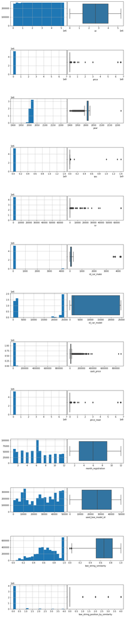

```python
numeric_vals = df.select_dtypes(exclude=['object']).shape[1]

fig, axes = plt.subplots(numeric_vals,2,figsize=(10, 55),gridspec_kw={'wspace': 0.01, 'hspace': 1})
axe = axes.ravel()

for col,i in zip(list(df.dtypes[df.dtypes != 'object'].index), range(0,numeric_vals*2,2)):
    if df[col].dtype != 'object':
        df[col].hist(bins=20, ax=axe[i])
        sns.boxplot(x=df[col], ax=axe[i+1])
```

## **Evaluación inicial**

### **Valores mal codificados**

A primera vista observamos una dispersión muy grande en las variables de precio, potencia (cv) y año. Las tablas nos muestran unos valores máximos claramente erroneos: una potencia de más de 65.000 caballos, precios desorbitados de cientos de millones de euros, y una distancia recorrida de 1.400 millones de km, que equivalen a prácticamente 5 viajes de ida y vuelta de la Tierra al Sol.

Es muy importante tratar todas estas observaciones de forma correcta. Nuestra base de datos está compuesta por gamas de vehículos muy diversas. No podemos simplemente establecer un baremo máximo, pues puede ser más erroneo un Dacia de 500 cv que un Lamborghini de 600 cv.

### **Asimetría**

Pese a la propia presencia de valores extremos mal codificados, nuestro dataset es, de por sí, muy asimétrico. Es mucho más común encontrar en el mercado de segunda mano un vehículo en un rango de precios entorno a 5.000 euros que, por ejemplo, de 60.000 en adelante, representando este último intervalo menos de un 1% de nuestros datos.

Sabemos también que la dispersión de precios aumenta a medida que lo hace el valor de un bien. Por lo tanto, cuanto más alto sea el precio, menor será el número de observaciones y mayor la dispersión de precio entre estas, lo que puede dificultar el entrenamiento de un modelo.

## **Decisiones sobre variables**

### Variables de plataforma web

La información recogida en el dataset tiene sentido en el contexto de los anuncios online. Sería coherente mantener todas las variables si quisiesemos, por ejemplo, predecir el precio que tendrá un vehículo subido a una determinada plataforma o vendido en una determinada ubicación.

Nuestra intención es, sin embargo, construir un algoritmo que sea capaz de tasar el valor de mercado de un vehículo dadas una serie de características tangibles de este. Por ello, vamos a empezar eliminando del dataset aquellas variables que, por su propia naturaleza, no encajan en el trabajo que queremos realizar.

```python
df = df.drop(['origin','url','creation_date','last_visit_date','refresh_date',
              'image_filename','postal_code','province', 'city',
             'boe_string_similarity','boe_string_position_by_similarity'], axis=1)
```

### Variables id

Las variables id identifican de alguna manera alguna de las características ya recogidas en otra variable. Esto supone un gran riesgo a la hora de entrenar nuestro modelo, pues podría producirse colinealidad y overfitting. Así pues, vamos a desecharlas.

```python
df = df.drop(['id','id_car_make','id_car_model','used_boe_model_id'], axis=1)
```

### Variables de precio

Esta es una de las decisiones más importantes que vamos a tomar, pues incumbe a nuestra variable objetivo.

Tenemos tres variables que recogen de algún modo el precio del vehículo: *cash_price, price_read* y *price*, siendo esta última nuestra varieble objetivo.

Como hemos definido anteriormente, **siempre** se leera un precio en la cabecera del anuncio que se almacenará en la variable *price_read*, mientras que **opcionalmente** el anunciante podrá indicar un precio de pago al contado del vehículo.

Por último, nuestra variable objetivo recogerá el valor al contado siempre que lo detecte, pues entiende que es un indicador más fiable del valor final del vehículo.

Naturalmente, no podremos disponer de ninguna de estas variables a la hora de tasar un vehículo, así que lo más sensato será quedarnos tan solo con la variable objetivo.

```python
df = df.drop(['cash_price', 'price_read'], axis=1)
```

### Resto de variables

Por último vamos a contabilizar el número de valores únicos y nulos en nuestras variables categóricas restantes.

```python
categorical_cols = list(df.select_dtypes(include=['object']).columns)

for col in categorical_cols:
    print(col)
    print(str(len(df[col].unique()))+'\n')
```

```
make
132

model
2419

version_tags
77961

basic_tags
232106

string_version
259470

model_boe
38526
```

```python
df[categorical_cols].isnull().sum()
```

```
make                    0
model                   0
version_tags            0
basic_tags              0
string_version     208352
model_boe         1004140
dtype: int64
```

La variable *model_boe* es una versión más limpia de la variable *string_version*. Lo que se hace es buscar en el registro de vehículos del BOE el modelo con mayor concordancia con el valor recogido en *string_version*, y ese es el valor que se le asigna a *model_boe*.

Por otro lado, estas variables detallan la información del modelo exacto del vehículo de una manera mucho más compleja y específica que la recogida en variables como *make*, *model* y *version_tags*. Nos interesa que nuestro modelo sea capaz de aprender y posteriormente generalizar, con lo cual nos quedaremos con la minima información indispensable. Por ello, procedemos a eliminar estas variable.

Por último, observamos que la variable *month_registration* tiene casi 4,7 millones de missings, lo que corresponde a casi el 90% de nuestros datos. Como no es una variable muy común, creemos que no tiene mucho sentido mantenerla en nuestro modelo.

```python
df = df.drop(['string_version','model_boe','month_registration'], axis=1)
```

Los anuncios de vehículos suelen publicarse en varias páginas a la vez, de modo que muchos de los vehículos del dataset estarán repetidos. Conviene eliminar estas observaciones duplicadas.

```python
df[df.duplicated()]
```

|  | make | model | price | version_tags | basic_tags | year | km | cv |
| --- | --- | --- | --- | --- | --- | --- | --- | --- |
| 11 | Land Rover | Range Rover Evoque | 27591 | {2.0,TD4,SE,Dynamic,150} | {5 puertas,Diesel,Automático,Color Negro} | 2017.0 | 54410.0 | 150.0 |
| 21 | Land Rover | Range Rover Evoque | 24455 | {2.0,TD4,HSE,Aut.,150} | {5 puertas,Faros de xenon,Aire Acondicionado,C... | 2017.0 | 27865.0 | 150.0 |
| 22 | Land Rover | Range Rover Evoque | 22272 | {150,2WD,SE} | {5 puertas,Aire Acondicionado,Climatizador,Con... | 2017.0 | 35186.0 | 150.0 |
| 26 | Land Rover | Range Rover Evoque | 22272 | {150,2WD,SE} | {5 puertas,Aire Acondicionado,Climatizador,Con... | 2017.0 | 35186.0 | 150.0 |
| 29 | Land Rover | Range Rover Evoque | 24455 | {2.0,TD4,HSE,Aut.,150} | {5 puertas,Faros de xenon,Aire Acondicionado,C... | 2017.0 | 27865.0 | 150.0 |
| ... | ... | ... | ... | ... | ... | ... | ... | ... |
| 5296438 | Land Rover | Range Rover Evoque | 19533 | {2.2L,TD4,Pure,4X4} | {3 puertas,Aire Acondicionado,Asientos calef.,... | 2014.0 | 113352.0 | 150.0 |
| 5296441 | Land Rover | Range Rover Evoque | 21600 | {2.0L,Si4,Dynamic,4X4} | {Faros de xenon,3 puertas,Aire Acondicionado,C... | 2012.0 | 120770.0 | 241.0 |
| 5296443 | Land Rover | Range Rover Evoque | 21900 | {2.0L,Si4,Dynamic,4X4} | {Faros de xenon,3 puertas,Aire Acondicionado,C... | 2012.0 | 120770.0 | 241.0 |
| 5296445 | Land Rover | Range Rover Evoque | 22500 | {2.2L,SD4,Pure,4X4,190} | {5 puertas,Faros de xenon,Aire Acondicionado,C... | 2013.0 | 101385.0 | 190.0 |
| 5296449 | Land Rover | Range Rover Evoque | 19533 | {2.2L,TD4,Pure,4X4} | {3 puertas,Aire Acondicionado,Asientos calef.,... | 2014.0 | 113352.0 | 150.0 |

2282788 rows × 8 columns

```python
df = df.drop_duplicates(keep='first', inplace=False)
```

```python
#Ordenamos nuestro dataframe
df = df.reset_index(drop=True)
df = df.sort_index()
```

# Feature engineering

Una vez eliminadas las variables que no necesitamos, podemos empezar el proceso de feature engineering sobre nuestro dataset.

Lo que buscamos es sacar el máximo partido a cada una de nuestras variables. Para ello nos valdremos de distintas transformaciones que puedan tener sentido en cada casuística concreta.

### Variables categóricas

En primer lugar, vamos a realizar feature engineering sobre nuestras variables categóricas.

Por un lado tenemos las variables *make* y *model*, que habrá que tratar para que agrupen correctamente las distintas tipologías de vehículo recogidas en nuestro dataset.

Vamos a realizar distintas transformaciones que por el momento almacenaremos en dos nuevas variables llamadas *make_processed* y *model_processed*.

#### Variable "make"

Empezamos con la variable *make*. Como hemos visto anteriormente, hace referencia a la marca concreta del vehículo.

```python
makes = list(df['make'].unique())
sorted(makes)
```

```
['9ff',
 'AC',
 'ASIA MOTORS',
 'AUVERLAND',
 'Abarth',
 'Acura',
 'Aixam',
 'Alfa Romeo',
 'Alpina',
 'Alpine',
 'Aro',
 'Asia',
 'Aston Martin',
 'Audi',
 'Austin',
 'Autobianchi',
 'BMW',
 'Bedford',
 'Bentley',
 'Bertone',
 'Borgward',
 'Bugatti',
 'Buick',
 'Cadillac',
 'Caravans-Wohnm',
 'Caterham',
 'Chatenet',
 'Chevrolet',
 'Chrysler',
 'Citroen',
 'Corvette',
 'Cupra',
 'DFSK',
 'DR AUTOMOBILES',
 'DR Motor',
 'DS',
 'DS Automobiles',
 'Dacia',
 'Daewoo',
 'Daihatsu',
```

[output cut: 77 more lines]

```
 'Talbot',
 'Tasso',
 'Tata',
 'Tesla',
 'Toyota',
 'Triumph',
 'Trucks-Lkw',
 'UAZ',
 'UMM',
 'VAZ',
 'Volkswagen',
 'Volvo',
 'Wartburg',
 'Westfield',
 'Wiesmann']
```

```python
len(makes)
```

```
132
```

Vemos que las marcas están escritas con mayúsculas y carácteres especiales. Esto conlleva que **Land Rover** sea considerada una marca distinta a **Land-Rover**. Vamos a pasar todas las marcas a minúsculas, quitar tildes (si las hubiese) y a reemplazar todos los espacios por guiones.

```python
df['make_processed'] = df['make'].str.lower()
df['make_processed'] = df['make_processed'].progress_apply(lambda x: unidecode.unidecode(x))
df['make_processed'] = df['make_processed'].progress_apply(lambda x: x.replace(' ','-'))
```

Por otro lado, observamos marcas que simplemente han sido anotadas de dos maneras, como es el caso de **asia** y **asia-motors**. Vamos a recodificar manualmente estas discrepancias para poder agrupar correctamente los vehículos de una misma marca.

```python
df.loc[(df['make_processed']=='asia-motors'),'make_processed'] = 'asia'
df.loc[(df['make_processed']=='dr-automobiles'),'make_processed'] = 'dr-motor'
df.loc[(df['make_processed']=='ds-automobiles'),'make_processed'] = 'ds'
df.loc[(df['make_processed']=='iveco-pegaso'),'make_processed'] = 'iveco'
df.loc[(df['make_processed']=='alpina'),'make_processed'] = 'bmw'
```

```python
makes = list(df['make_processed'].unique())
sorted(makes)
```

```
['9ff',
 'abarth',
 'ac',
 'acura',
 'aixam',
 'alfa-romeo',
 'alpine',
 'aro',
 'asia',
 'aston-martin',
 'audi',
 'austin',
 'autobianchi',
 'auverland',
 'bedford',
 'bentley',
 'bertone',
 'bmw',
 'borgward',
 'bugatti',
 'buick',
 'cadillac',
 'caravans-wohnm',
 'caterham',
 'chatenet',
 'chevrolet',
 'chrysler',
 'citroen',
 'corvette',
 'cupra',
 'dacia',
 'daewoo',
 'daihatsu',
 'daimler',
 'dangel',
 'de-tomaso',
 'dfsk',
 'dodge',
 'dr-motor',
 'ds',
```

[output cut: 71 more lines]

```
 'tasso',
 'tata',
 'tesla',
 'toyota',
 'triumph',
 'trucks-lkw',
 'tvr',
 'uaz',
 'umm',
 'vaz',
 'volkswagen',
 'volvo',
 'wartburg',
 'westfield',
 'wiesmann']
```

#### Variable "model"

En esta variable necesitaremos realizar una limpieza más exhaustiva, pues existe una gran cantidad de modelos muy concretos para cada gama de vehículos.

Además, la notación entre dos modelos iguales puede ser distinta como hemos visto anteriormente. Sin embargo, en este caso nos encontramos con más de 2.400 modelos diferentes, lo cual no hace muy viable revisar manualmente cada uno de ellos.

```python
models = list(df['model'].unique())
sorted(models)
```

```
['+4',
 '01',
 '1.2 T OPALO 116 CV',
 '10',
 '100',
 '100 NX',
 ...]
```

```python
len(models)
```

```
2419
```

Para agrupar al maximo las tipologías más similares, podemos realizar una serie de transformaciones. En la mayoría de casos, los 3 primeros caracteres identifican con bastante precisión el modelo al que nos referimos. Podemos hacer un procesado que elimine todos los separadores y quedarnos únicamente con un identificador de 3 caracteres.

De este modo, modelos como **Clio**, **Clio RS** y **Clio V6** quedarían agrupados en una misma categoría **cli**.

```python
df['model_processed'] = df['model'].progress_apply(lambda x: x.replace(" ",""))
df['model_processed'] = df['model_processed'].str.lower()
df['model_processed'] = df['model_processed'].progress_apply(lambda x: unidecode.unidecode(x))
df['model_processed'] = df['model_processed'].progress_apply(lambda x: x.replace('\'',''))
df['model_processed'] = df['model_processed'].progress_apply(lambda x: x.replace('/',''))
df['model_processed'] = df['model_processed'].progress_apply(lambda x: x.replace('.',''))
df['model_processed'] = df['model_processed'].progress_apply(lambda x: x.replace('-',''))
df['model_processed'] = df['model_processed'].progress_apply(lambda x: x.replace('+','p'))
df['model_processed'] = df['model_processed'].progress_apply(lambda x: x[:3]) #Prueba borrando esta linea y viendo si mejora o empeora el score
```

```python
models = list(df['model_processed'].unique())
models = sorted(models)
for model in models:
    print(model)
```

```
01
10
100
105
106
107
...
```

```python
len(models)
```

```
1322
```

Con este paso, además de agrupar modelos muy similares, conseguimos reducir casi a la mitad la cantidad de categorías de la variable *model*, aunque sigue siendo muy elevada.

Concatenamos las variables *make*-*model* para dar paso a una nueva variable que crearemos de forma temporal, denominada *make_model*. De este modo, tendremos una única variable categórica.

```python
df['make_model'] = df['make_processed'] + '-' + df['model_processed']
```

#### Variable "decade"

Creamos una variable para clasificar en rangos la antiguedad del vehículo. Esta categoría nos servirá para crear una distinción adicional entre marcas y modelos, para que las ediciones de distintas épocas no queden solapadas.

```python
df['decade'] = ''
df.loc[df['year'].between(0,1969),'decade'] = 'Anterior a 1970'
df.loc[df['year'].between(1970,1979),'decade'] = '70s'
df.loc[df['year'].between(1980,1989),'decade'] = '80s'
df.loc[df['year'].between(1990,1999),'decade'] = '90s'
df.loc[df['year'].between(2000,2009),'decade'] = '2000s'
df.loc[df['year'].between(2010,2019),'decade'] = '2010s'
df.loc[df['year'].between(2020,2021),'decade'] = '2020s'
```

#### Variable "basic_tags"

Esta variable recoge diferentes tags sobre características concretas de cada vehículo, de las cuales podemos extraer features para construir nuevas variables.

Realizamos un primer procesado para eliminar mayúsculas, tildes y, de paso, convertir nuestra variable a lista, para que sea más cómodo trabajar con ella. A continuación, crearemos un diccionario de frecuencias para ver qué tags se repiten más.

En primer lugar, definimos algunas funciones que nos serán de utilidad.

```python
# Función que elimina las tildes dada una lista de tokens

def remove_accents(tokens):
    words=[unidecode.unidecode(word) for word in tokens]
    return words

# Función que crea un diccionario de frecuencias dada una lista de tokens

def tokens_frequency(lista):
    frequency = {}                           #Definimos un diccinario vacío
    for item in lista:                        #Recorremos cada item de la lista
        if (item in frequency):
            frequency[item] += 1
        else:
            frequency[item] = 1              #Si el item no tenía entrada previamente, se crea; por el contrario, se suma 1 a su valor previo
    return frequency
```

```python
df['basic_tags'] = df['basic_tags'].progress_apply(lambda x: x.replace('{',''))
df['basic_tags'] = df['basic_tags'].progress_apply(lambda x: x.replace('}',''))
df['basic_tags'] = df['basic_tags'].str.lower()
df['basic_list'] = df['basic_tags'].progress_apply(lambda x: x.split(","))
df['basic_list'] = df['basic_list'].progress_apply(lambda x: remove_accents(x))
```

```python
tags_list = list()
for i in df["basic_list"]:
    tags_list.extend(i)
```

```python
dict_freq_tags = tokens_frequency(tags_list)
```

```python
len(dict_freq_tags)
```

```
952
```

```python
sorted(dict_freq_tags.items(), key=lambda x: x[1])
```

```
[('color 3p0 rojo classic', 1),
 ('color soul red crystal', 1),
 ('color bi-tono blanco / negro', 1),
 ('color bitono blanco glarciar', 1),
 ('color bitono blanco glacial y techo', 1),
 ...
```

Hay una gran cantidad de tags referentes a colores. Estos tags no son buenos, pues son demasiado específicos y, salvo excepciones concretas, no nos dicen mucho sobre el valor de un vehículo. Por ello, procedemos a eliminarlos.

```python
# Función que elimina los tags referentes a colores, pues son demasiados

def remove_color(tokens):
    words=[]
    for word in tokens:
        if 'color' not in word:
            words.append(word)
    return words


df['basic_list'] = df['basic_list'].progress_apply(lambda x: remove_color(x))
```

Una vez eliminados todos los tags innecesarios, redefinimos nuestro diccionario de frecuencias.

```python
list_tags = list()
for i in df["basic_list"]:
    list_tags.extend(i)
```

```python
dict_tags_freq = tokens_frequency(list_tags)
```

```python
len(dict_tags_freq)
```

```
168
```

Ahora podemos visualizar cuales son los tags más frecuentes en nuestra variable.

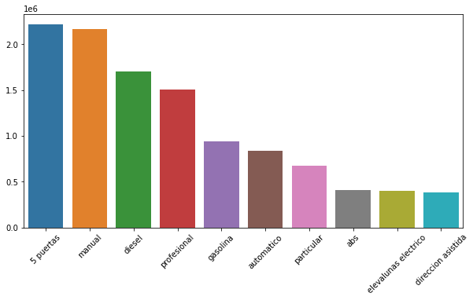

```python
# Nos interesan solo los 10 tokens más frecuentes, así que ordenamos nuestro diccionario (por valor) en orden descendente y seleccionamos las 10 primeras entradas

dict_freq_order = sorted(dict_tags_freq.items(), key=lambda x: x[1], reverse=True)[:10]
token_names = list()
token_freqs = list()
for i in dict_freq_order:
    token_names.append(i[0])                  #Almacenamos las etiquetas
    token_freqs.append(i[1])                  #Almacenamos las frecuencias

# Representamos las variables

plt.rcParams['figure.figsize'] = [10, 5]
sns_g = sns.barplot(x=token_names, y=token_freqs)
plt.xticks(rotation=45)
plt.show()
```

Tenemos una gran cantidad de información respecto al número de puertas, el tipo de cambio, el tipo de combustible utilizado y si el vehículo es vendido por un profesional o un particular.

Estos tags pueden ser muy útiles pues en la práctica son características del vehículo muy fácilmente identificables.

Vamos a definir dos nuevas funciones que nos ayuden a crear las nuevas variables.

```python
# En primer lugar, creamos variables con las categorías que consideramos relevantes para cada una

fuel = ['diesel','gasolina']
gearshift = ['automatico','manual']
doors = ['5 puertas','4 puertas','3 puertas','2 puertas']
scope = ['profesional','particular']

features_total = fuel+gearshift+doors+scope

# Extraemos las features elegidas previamente. Si no se encuentra, el valor se definirá como 'otro'

def extract_single_feature(tokens, features):
    filtered = ''.join([w for w in tokens if w in features])
    if filtered not in features:
        filtered = 'otro'
    return filtered

# Con esta función podremos contabilizar todas aquellas features que no corresponde a ninguna de las establecidas anteriormente

def count_features(tokens, features):
    count = 0
    for token in tokens:
        if token not in features:
            count += 1
    return count
```

Pasamos a aplicarlas sobre nuestra variable *basic_lista* para poder crear las nuevas columnas.

```python
df['fuel'] = df['basic_list'].apply(lambda x: extract_single_feature(x, fuel))
df['gearshift'] = df['basic_list'].apply(lambda x: extract_single_feature(x, gearshift))
df['doors'] = df['basic_list'].apply(lambda x: extract_single_feature(x, doors))
df['scope'] = df['basic_list'].apply(lambda x: extract_single_feature(x, scope))
df['n_basic_extra'] = df['basic_list'].apply(lambda x: count_features(x, features_total))
```

```python
for col in ['fuel','gearshift','doors','scope']:
    print('\n'+col)
    print(df[col].value_counts()/df[col].value_counts().sum())
```

```
fuel
diesel      0.565016
gasolina    0.312670
otro        0.122314
Name: fuel, dtype: float64

gearshift
manual        0.718427
automatico    0.278343
otro          0.003230
Name: gearshift, dtype: float64

doors
5 puertas    0.736063
3 puertas    0.106803
4 puertas    0.104840
2 puertas    0.043224
otro         0.009070
Name: doors, dtype: float64

scope
profesional    0.498577
otro           0.277357
particular     0.224066
Name: scope, dtype: float64
```

#### Variable "version_tags"

Repetimos el proceso anterior para la variable *version_tags*.

```python
df['version_tags'] = df['version_tags'].progress_apply(lambda x: x.replace('{',''))
df['version_tags'] = df['version_tags'].progress_apply(lambda x: x.replace('}',''))
df['version_list'] = df['version_tags'].str.lower()
df['version_list'] = df['version_list'].progress_apply(lambda x: x.split(","))
df['version_list'] = df['version_list'].progress_apply(lambda x: remove_accents(x))
```

```python
model_list = list()
for i in df["version_list"]:
    model_list.extend(i)
```

```python
dict_model_freq = tokens_frequency(model_list)
```

```python
del dict_model_freq['']
sorted(dict_model_freq.items(), key=lambda x: x[1], reverse=True)
```

```
[('tdi', 242371),
 ('2.0', 220070),
 ('1.6', 208598),
 ('d', 104249),
 ('dci', 92955),
 ...]
```

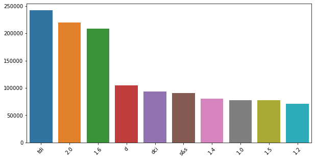

```python
# Nos interesan solo los 10 tokens más frecuentes, así que ordenamos nuestro diccionario (por valor) en orden descendente y seleccionamos las 10 primeras entradas

dict_freq_order = sorted(dict_model_freq.items(), key=lambda x: x[1], reverse=True)[:10]
token_names = list()
token_freqs = list()
for i in dict_freq_order:
    token_names.append(i[0])
    token_freqs.append(i[1])

# Representamos las variables

plt.rcParams['figure.figsize'] = [10, 5]
sns_g = sns.barplot(x=token_names, y=token_freqs)
plt.xticks(rotation=45)
plt.show()
```

```python
version_num_dec = ['1.0','1.2','1.4','1.5','1.6','1.9','2.0']
version_engine = ['tdi','s&s','dci','hdi','tdci','tsi','d','bluehdi']
version_other = ['sport','style','advance','4x2']

features_total = version_num_dec+version_engine+version_other

df['version_num_dec'] = df['version_list'].apply(lambda x: extract_single_feature(x, version_num_dec))
df['version_engine'] = df['version_list'].apply(lambda x: extract_single_feature(x, version_engine))
df['version_other'] = df['version_list'].apply(lambda x: extract_single_feature(x, version_other))
df['n_version_extra'] = df['version_list'].apply(lambda x: count_features(x, features_total))
```

En este caso los tags son mucho más variados y por lo tanto menos generalizables, pero mantendremos algunos de los más observados a lo largo del dataset.

```python
for col in ['version_num_dec','version_engine','version_other']:
    print('\n'+col)
    print(df[col].value_counts()/df[col].value_counts().sum())
```

```
version_num_dec
otro    0.743706
2.0     0.073023
1.6     0.069177
1.4     0.026609
1.0     0.025712
1.5     0.025553
1.2     0.023486
1.9     0.012734
Name: version_num_dec, dtype: float64

version_engine
otro       0.774453
tdi        0.077704
d          0.034528
dci        0.029119
s&s        0.018136
hdi        0.016904
bluehdi    0.016420
tsi        0.016414
tdci       0.016321
Name: version_engine, dtype: float64

version_other
otro       0.927855
4x2        0.019220
advance    0.018733
sport      0.018523
style      0.015668
Name: version_other, dtype: float64
```

Una vez realizada la extracción de tokens, podemos eliminar las variables *basic_tags* y *version_tags*, así como sus versiones en lista, pues ya han cumplido su función.

```python
df = df.drop(['basic_tags','version_tags','basic_list','version_list'], axis=1)
```

## Tratamiento de valores mal codificados

Después de realizar Feature Engineering sobre las variables categóricas, tenemos más herramientas para segmentar y tratar las variables numéricas en busca de anomalias.

La identificación de valores erróneamente codificados puede ser complicada debido a las diferencias entre gamas de vehículos. Como hemos expuesto anteriormente, no podemos fijar un baremo general, pues un valor anormal para un modelo concreto podría ser perfectamente común en otro. Para resolver un problema de esta magnitud podemos recurrir a distintas técnicas estadísticas de deteccion de valores anómalos.

Aplicaremos estas técnicas a distintos niveles para eliminar el máximo número de valores extremos. Nos interesa que la distribución final de nuestros datos sea lo más regular posible, pues queremos que el algoritmo aprenda de aquellas observaciones más centricas pues son las que se observan con mayor frecuencia.

### Z-Score y Rango Intercuartílico

Primeramente tratamos los valores del dataset más extremos que podrían sesgar el cálculo posterior de la matriz de covarianzas. Para ello haremos uso de dos medidas estadísticas que nos permitirán identificar los valores que quedan más alejados de la distribución de cada variable de forma independiente.

La primera es la **Unidad Tipificada** o **Z-Score**, que mide en cuantas desviaciones típicas o desviaciones medianas se aleja un valor determinado de la media o mediana poblacional, respectivamente.

El segundo es la estimación del **Rango Intercuartílico**, que se define como la distancia entre el primer y el tercer cuartil de un conjunto de datos.

Para el **Z-Score** establecemos un límite de 3 desviaciones medianas de distancia con respecto a la mediana. Usamos esta métrica en lugar de la media ya que puede estar sesgada por las observaciones mal codificadas al tener valores muy extremos. Con el **Rango Intercuartílico** los limites inferior y superior estarán 3 rangos intercuartílicos por debajo del primer cuartil o 3 rangos intercuartílicos por encima del tercer cuartil, respectivamente.

Calculamos distintas métricas para las variables *price*, *cv* y *km*, que son las que tienen mayor cantidad de valores mal codificados. Estimamos los estadísticos enumerados y catalogamos como valores erróneos aquellos que satifagan ambos criterios simultáneamente.

```python
def calculateMetrics(dataframe, col,model,decade):
    df_output = dataframe.groupby([model,decade]).agg({col: [lambda x: x.quantile(q = 0.25),
                                                             lambda x: x.quantile(q = 0.75),
                                                             lambda x: x.quantile(q = 0.75)-x.quantile(q = 0.25),
                                                             'mean',
                                                             'median',
                                                             'std',
                                                             'mad',
                                                             'min',
                                                             'max']})
    cols = []
    base = ['Q25_','Q75_','IQR_','mean_','median_','std_','mad_','min_','max_']
    for i in base:
        cols.append(i+col)
    df_output.columns = cols
    return df_output


def outlierCriterion(dataframe, col):
    dataframe['zscore_criterion_'+col] = (abs(dataframe[col]-dataframe['median_'+col])/dataframe['mad_'+col])>3
    dataframe['iqr_outlier_criterion_'+col] = ((dataframe[col]<(dataframe['Q25_'+col] - 3*dataframe['IQR_'+col]))|(dataframe[col]>(dataframe['Q75_'+col] + 3*dataframe['IQR_'+col])))
    df_output = dataframe.loc[(dataframe['zscore_criterion_'+col]==True)&(dataframe['iqr_outlier_criterion_'+col]==True)]
    return df_output
```

```python
df_price = calculateMetrics(df, 'price','make_model','decade')
```

```python
df = df.join(df_price, on=['make_model','decade'])
```

Visualizando las observaciones, vemos que son claramente erroneas, así que las eliminamos.

```python
df_price_outliers = outlierCriterion(df, 'price')
```

```python
df_price_outliers.sort_values(by='price')
```

|  | make | model | price | year | km | cv | make_processed | model_processed | make_model | decade | ... | Q75_price | IQR_price | mean_price | median_price | std_price | mad_price | min_price | max_price | zscore_criterion_price | iqr_outlier_criterion_price |
| --- | --- | --- | --- | --- | --- | --- | --- | --- | --- | --- | --- | --- | --- | --- | --- | --- | --- | --- | --- | --- | --- |
| 125258 | Hyundai | Tucson | 0 | 2017.0 | 72000.0 | 176.0 | hyundai | tuc | hyundai-tuc | 2010s | ... | 19990.0 | 3990.0 | 1.831141e+04 | 17900.0 | 4.024375e+03 | 2.627204e+03 | 0 | 179900 | True | True |
| 903429 | Porsche | Taycan | 0 | 2020.0 | 276.0 | 435.0 | porsche | tay | porsche-tay | 2020s | ... | 151125.0 | 34127.5 | 1.360077e+05 | 130000.0 | 2.607543e+04 | 2.057361e+04 | 0 | 239450 | True | True |
| 1894694 | Ferrari | 612 | 0 | 2007.0 | 80000.0 | 540.0 | ferrari | 612 | ferrari-612 | 2000s | ... | 76999.0 | 7009.0 | 7.423045e+04 | 76999.0 | 1.346965e+04 | 8.079678e+03 | 0 | 102500 | True | True |
| 903239 | Renault | Kadjar | 0 | 2016.0 | 10000.0 | 160.0 | renault | kad | renault-kad | 2010s | ... | 18400.0 | 3900.0 | 1.642639e+04 | 16490.0 | 2.815198e+03 | 2.190236e+03 | 0 | 70000 | True | True |
| 2574884 | Renault | Kadjar | 0 | 2018.0 | 16900.0 | 160.0 | renault | kad | renault-kad | 2010s | ... | 18400.0 | 3900.0 | 1.642639e+04 | 16490.0 | 2.815198e+03 | 2.190236e+03 | 0 | 70000 | True | True |
| ... | ... | ... | ... | ... | ... | ... | ... | ... | ... | ... | ... | ... | ... | ... | ... | ... | ... | ... | ... | ... | ... |
| 1399307 | Nissan | Qashqai | 300099999 | 2010.0 | 180000.0 | NaN | nissan | qas | nissan-qas | 2010s | ... | 18600.0 | 6600.0 | 3.705973e+04 | 15500.0 | 2.535565e+06 | 4.352847e+04 | 0 | 300099999 | True | True |
| 759432 | Volkswagen | ID.4 | 627377197 | 2001.0 | 447800.0 | 110.0 | volkswagen | id4 | volkswagen-id4 | 2000s | ... | 5500.0 | 3400.0 | 3.979727e+04 | 3500.0 | 4.614541e+06 | 7.077257e+04 | 0 | 627377197 | True | True |
| 1870099 | Volkswagen | Golf | 631532797 | 2005.0 | 300000.0 | NaN | volkswagen | gol | volkswagen-gol | 2000s | ... | 5990.0 | 3540.0 | 3.971032e+04 | 3900.0 | 4.707004e+06 | 7.018524e+04 | 0 | 631532797 | True | True |
| 1075518 | Peugeot | Partner | 662378766 | 2017.0 | 80500.0 | 99.0 | peugeot | par | peugeot-par | 2010s | ... | 10600.0 | 3950.0 | 1.124802e+05 | 8500.0 | 8.286750e+06 | 2.073145e+05 | 0 | 662378766 | True | True |
| 1064320 | Renault | Latitude | 669840793 | 2012.0 | 35000.0 | 150.0 | renault | lat | renault-lat | 2010s | ... | 8995.0 | 2495.0 | 2.858089e+06 | 7800.0 | 4.369509e+07 | 5.676449e+06 | 0 | 669840793 | True | True |

21782 rows × 30 columns

```python
df = df.drop(df_price_outliers.index, axis=0)
```

```python
df_cv = calculateMetrics(df, 'cv','make_model','decade')
```

```python
df = df.join(df_cv, on=['make_model','decade'])
```

```python
df_cv_outliers = outlierCriterion(df, 'cv')
```

```python
df_cv_outliers.sort_values(by='cv')
```

|  | make | model | price | year | km | cv | make_processed | model_processed | make_model | decade | ... | Q75_cv | IQR_cv | mean_cv | median_cv | std_cv | mad_cv | min_cv | max_cv | zscore_criterion_cv | iqr_outlier_criterion_cv |
| --- | --- | --- | --- | --- | --- | --- | --- | --- | --- | --- | --- | --- | --- | --- | --- | --- | --- | --- | --- | --- | --- |
| 2822088 | Peugeot | Boxer | 5000 | 2004.0 | 187562.0 | 0.0 | peugeot | box | peugeot-box | 2000s | ... | 120.0 | 20.0 | 109.703170 | 110.0 | 19.731904 | 15.105316 | 0.0 | 160.0 | True | True |
| 2829199 | Mazda | 6 | 2800 | 2007.0 | 130000.0 | 0.0 | mazda | 6 | mazda-6 | 2000s | ... | 143.0 | 22.0 | 139.461794 | 140.0 | 30.088359 | 16.397391 | 0.0 | 260.0 | True | True |
| 485694 | Volkswagen | T3 Multivan | 7497 | 1994.0 | 374855.0 | 0.0 | volkswagen | t3m | volkswagen-t3m | 90s | ... | 77.0 | 4.0 | 72.636364 | 77.0 | 27.789468 | 14.710744 | 0.0 | 120.0 | True | True |
| 2513161 | Mercedes-Benz | Sprinter | 3500 | 1995.0 | 198103.0 | 0.0 | mercedes-benz | spr | mercedes-benz-spr | 90s | ... | 122.0 | 22.5 | 119.722689 | 122.0 | 81.184653 | 25.047949 | 0.0 | 900.0 | True | True |
| 2795040 | Toyota | RAV 4 | 23500 | 2016.0 | 77400.0 | 0.0 | toyota | rav | toyota-rav | 2010s | ... | 197.0 | 47.0 | 177.002277 | 197.0 | 30.286378 | 27.811215 | 0.0 | 280.0 | True | True |
| ... | ... | ... | ... | ... | ... | ... | ... | ... | ... | ... | ... | ... | ... | ... | ... | ... | ... | ... | ... | ... | ... |
| 2728631 | Hyundai | Tucson | 3000 | 2005.0 | NaN | 65535.0 | hyundai | tuc | hyundai-tuc | 2000s | ... | 140.0 | 25.0 | 196.496965 | 140.0 | 1854.373117 | 125.993222 | 0.0 | 65535.0 | True | True |
| 2508564 | Ford | Mondeo | 1250 | 2005.0 | 170000.0 | 65535.0 | ford | mon | ford-mon | 2000s | ... | 140.0 | 20.0 | 140.212411 | 130.0 | 663.416692 | 24.307350 | 1.0 | 65535.0 | True | True |
| 2598687 | Toyota | Auris | 8000 | 2011.0 | 85000.0 | 65535.0 | toyota | aur | toyota-aur | 2010s | ... | 136.0 | 20.0 | 132.698337 | 136.0 | 634.289919 | 16.863835 | 1.0 | 65535.0 | True | True |
| 2625456 | Volkswagen | Touran | 11990 | 2016.0 | 197000.0 | 65535.0 | volkswagen | tou | volkswagen-tou | 2010s | ... | 150.0 | 40.0 | 149.919543 | 116.0 | 672.170342 | 47.378236 | 1.0 | 65535.0 | True | True |
| 97778 | SEAT | CÓRDOBA | 350 | 1995.0 | 200000.0 | 65535.0 | seat | cor | seat-cor | 90s | ... | 90.0 | 15.0 | 216.240157 | 90.0 | 2902.604820 | 259.754015 | 3.0 | 65535.0 | True | True |

51330 rows × 41 columns

```python
df = df.drop(df_cv_outliers.index, axis=0)
```

```python
df_km = calculateMetrics(df, 'km','make_model','decade')
```

```python
df = df.join(df_km, on=['make_model','decade'])
```

```python
df_km_outliers = outlierCriterion(df, 'km')
```

```python
df_km_outliers.sort_values(by='km')
```

|  | make | model | price | year | km | cv | make_processed | model_processed | make_model | decade | ... | Q75_km | IQR_km | mean_km | median_km | std_km | mad_km | min_km | max_km | zscore_criterion_km | iqr_outlier_criterion_km |
| --- | --- | --- | --- | --- | --- | --- | --- | --- | --- | --- | --- | --- | --- | --- | --- | --- | --- | --- | --- | --- | --- |
| 2926109 | Volkswagen | T2 | 22000 | 1980.0 | 1.000000e+00 | 60.0 | volkswagen | t2 | volkswagen-t2 | 80s | ... | 87225.50 | 11055.5 | 7.415891e+04 | 76850.0 | 2.981120e+04 | 1.834306e+04 | 1.0 | 1.140000e+05 | True | True |
| 2980222 | Alfa Romeo | 159 | 350 | 2014.0 | 3.000000e+00 | NaN | alfa-romeo | 159 | alfa-romeo-159 | 2010s | ... | 190000.00 | 44000.0 | 1.744896e+05 | 166000.0 | 5.703193e+04 | 4.057727e+04 | 3.0 | 3.400000e+05 | True | True |
| 1991341 | Chevrolet | Camaro | 6990 | 2001.0 | 1.000000e+01 | 198.0 | chevrolet | cam | chevrolet-cam | 2000s | ... | 138000.00 | 17000.0 | 1.152397e+05 | 130000.0 | 4.241318e+04 | 3.060563e+04 | 10.0 | 1.600000e+05 | True | True |
| 1971226 | Audi | S6 | 1 | 1997.0 | 3.000000e+01 | 230.0 | audi | s6 | audi-s6 | 90s | ... | 231250.00 | 40750.0 | 2.034614e+05 | 198598.5 | 7.616060e+04 | 4.913092e+04 | 30.0 | 3.500000e+05 | True | True |
| 1650963 | SsangYong | Rexton | 32950 | 2021.0 | 6.000000e+01 | 181.0 | ssangyong | rex | ssangyong-rex | 2020s | ... | 28.75 | 6.0 | 2.685714e+01 | 25.0 | 1.669112e+01 | 1.036735e+01 | 1.0 | 6.000000e+01 | True | True |
| ... | ... | ... | ... | ... | ... | ... | ... | ... | ... | ... | ... | ... | ... | ... | ... | ... | ... | ... | ... | ... | ... |
| 588576 | Audi | A4 | 1000 | 2002.0 | 1.677722e+07 | NaN | audi | a4 | audi-a4 | 2000s | ... | 273000.00 | 99000.0 | 2.283435e+05 | 220000.0 | 1.956971e+05 | 7.005408e+04 | 1.0 | 1.677722e+07 | True | True |
| 1664471 | Porsche | Cayenne | 34400 | 2014.0 | 1.218320e+08 | NaN | porsche | cay | porsche-cay | 2010s | ... | 160000.00 | 104000.0 | 1.329287e+05 | 106000.0 | 1.593993e+06 | 8.138433e+04 | 10.0 | 1.218320e+08 | True | True |
| 436021 | Oldtimer | Lancia | 94900 | 1957.0 | 1.000000e+09 | NaN | oldtimer | lan | oldtimer-lan | Anterior a 1970 | ... | 999999.00 | 992199.0 | 1.253889e+08 | 549999.0 | 3.533966e+08 | 2.186528e+08 | 12.0 | 1.000000e+09 | True | True |
| 2493778 | Ford | C-Max | 11990 | 2014.0 | 1.299065e+09 | 116.0 | ford | cma | ford-cma | 2010s | ... | 138000.00 | 79350.0 | 2.559379e+05 | 95000.0 | 1.410597e+07 | 3.081353e+05 | 1.0 | 1.299065e+09 | True | True |
| 2010882 | Kia | Ceed SW / cee'd SW | 6990 | 2016.0 | 1.400000e+09 | 110.0 | kia | cee | kia-cee | 2010s | ... | 100000.00 | 80365.0 | 2.982077e+05 | 50560.5 | 1.795091e+07 | 4.612363e+05 | 1.0 | 1.400000e+09 | True | True |

10912 rows × 52 columns

```python
df = df.drop(df_km_outliers.index, axis=0)
```

Eliminamos las métricas calculadas. No conviene mantenerlas ya que muchas de ellas pueden estar sesgadas por los valores que hemos eliminado.

```python
df = df.drop(['mean_price','std_price','Q25_price', 'Q75_price', 'IQR_price', 'median_price',
              'mad_price','min_price', 'max_price', 'zscore_criterion_price','iqr_outlier_criterion_price',
              'mean_cv', 'std_cv','Q25_cv', 'Q75_cv', 'IQR_cv','median_cv', 'mad_cv', 'min_cv', 'max_cv',
              'zscore_criterion_cv','iqr_outlier_criterion_cv','mean_km', 'std_km','Q25_km', 'Q75_km',
              'IQR_km', 'median_km','mad_km', 'min_km', 'max_km', 'zscore_criterion_km',
              'iqr_outlier_criterion_km'],axis=1)
```

### Distancia de Mahalanobis

La Distancia de Mahalanobis mide la distancia entre dos observaciones definidas por *n* variables aleatorias en el plano multidimensional. Nos permitirá identificar aquellas observaciones cuyas variables quedan más alejadas de la distribución.

Esta medida, a diferencia de la distancia Euclidea, tiene en cuenta las correlaciones entre variables, tal y como se puede observar en la imagen adjunta.

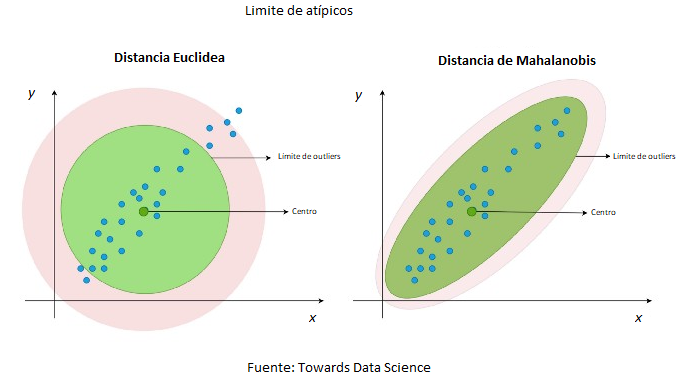

Para calcular la distancia de Mahalanobis es necesario estimar la matriz de covarianzas. Para evitar errores en el cálculo, hay que cerciorarse de que:

- No queden valores NA.
- No haya combinaciones de marca y modelo con una única observación.

Al existir modelos con pocos registros y datos incompletos, es necesario realizar un tratamiento previo de los datos.

```python
df.isnull().sum()
```

```
make                    0
model                   0
price                   0
year                 6736
km                  24813
cv                 615622
make_processed          0
model_processed         0
make_model              0
decade                  0
fuel                    0
gearshift               0
doors                   0
scope                   0
n_basic_extra           0
version_num_dec         0
version_engine          0
version_other           0
n_version_extra         0
dtype: int64
```

La mayor cantidad de missings se concentra en la variable *cv*. Por fortuna, esta variable es fácilmente imputable a partir de otros vehículos similares.

Agrupamos los vehículos por marca y modelo e imputamos los missings por la mediana. Nos decantamos nuevamente por esta métrica en lugar de la media debido a su mayor robustez.

```python
df_year = df.groupby(['make_processed', 'model_processed']).agg({'year': ['median']})
df_year.columns = ['median_year']
df_km = df.groupby(['make_processed', 'model_processed']).agg({'km': ['median']})
df_km.columns = ['median_km']
df_cv = df.groupby(['make_processed', 'model_processed']).agg({'cv': ['median']})
df_cv.columns = ['median_cv']
```

```python
df.columns
```

```
Index(['make', 'model', 'price', 'year', 'km', 'cv', 'make_processed',
       'model_processed', 'make_model', 'decade', 'fuel', 'gearshift', 'doors',
       'scope', 'n_basic_extra', 'version_num_dec', 'version_engine',
       'version_other', 'n_version_extra'],
      dtype='object')
```

```python
df = df.join(df_year, on=['make_processed', 'model_processed'])
df = df.join(df_km, on=['make_processed', 'model_processed'])
df = df.join(df_cv, on=['make_processed', 'model_processed'])
```

```python
df['cv'].fillna(df['median_cv'], inplace=True)
df['year'].fillna(df['median_year'], inplace=True)
df['km'].fillna(df['median_km'], inplace=True)
```

```python
df.isnull().sum()
```

```
make                 0
model                0
price                0
year                 0
km                   3
cv                 230
make_processed       0
model_processed      0
make_model           0
decade               0
fuel                 0
gearshift            0
doors                0
scope                0
n_basic_extra        0
version_num_dec      0
version_engine       0
version_other        0
n_version_extra      0
median_year          0
median_km            3
median_cv          230
dtype: int64
```

Quedan algunas observaciones cuyos valores nulos no pueden ser imputados con esta técnica. Esto ocurre porque no existe un solo vehículo de esa marca y modelo que tenga datos sobre esa variable. Esto ocurre con vehículos con muy escasas observaciones, así que vamos a prescindir de ellos.

```python
df = df.loc[df['cv'].notnull()]
df = df.loc[df['km'].notnull()]
```

Definimos una lista con todas las combinaciones de marca y modelo cuyo número de observaciones es superior a 1.

```python
make_model_count = df['make_model'].value_counts()
make_model_unique_list = list(make_model_count[make_model_count > 1].index)
```

Eliminamos las medianas, pues ya no las necesitamos.

```python
df = df.drop(['median_cv','median_km','median_year'], axis=1)
```

Calculamos la distancia de Mahalanobis, segmentando los datos de manera independiente para cada marca, modelo y década. De esta manera, evitaremos que vehículos con precios y potencias altas en la actualidad desplacen modelos más antiguos cuyos valores son correctos.

```python
from scipy.spatial.distance import mahalanobis
import scipy as sp
from scipy.stats import chi2


def mahalanobisMake(Sx, features):
    global df
    global df_model
    Sx = sp.linalg.inv(Sx)

    mean = x.mean().values

    mahalanobisDistance = []
    for i in range(x.shape[0]):
        mahalanobisDistance.append(mahalanobis(x.iloc[i,:],mean,Sx) ** 2)

    df_model['mahalanobis'] = mahalanobisDistance
    df_model['p'] = 1 - chi2.cdf(df_model['mahalanobis'], len(features)-1)
    df_model['make_model'] = make_model
    df_model = df_model[['make_model','mahalanobis','p']]
    df_model = df_model.set_index('make_model')
    df.loc[(df['make_model']==make_model)&(df['decade']==decade),'mahalanobis'] = list(df_model['mahalanobis'])
    df.loc[(df['make_model']==make_model)&(df['decade']==decade),'p'] = list(df_model['p'])
```

Creamos un bucle que, para cada marca/modelo/década:

- Creará un dataframe con las features que comprenden el espacio de características.
- Calculará la Distancia de Mahalanobis y estimará el *p-valor* de su distribución.
- Si alguna feature es identica para cada observación, se prescindirá de esta, ajustando los grados de libertad del *p-valor*.

```python
year_ranges = ['Anterior a 1970','70s','80s','90s','2000s','2010s','2020s']

for decade in year_ranges:
    for make_model in make_model_unique_list:
        features = ['price','cv','year','km']
        df_model = df.loc[(df['make_model']==make_model)&(df['decade']==decade),features]
        if len(df_model) > 5:
            x = df_model.iloc[:,1:]

            Sx = x.cov().values

            if np.linalg.det(Sx):
                mahalanobisMake(Sx, features)

            # Si todos los vehículos tienen exactamente la misma potencia, prescindimos de la feature 'cv'
            elif np.all(Sx[:,0] == 0)&np.all(np.sum(Sx[:,np.r_[1,2]], axis=0) != 0):
                features = ['price','year','km']
                df_model = df.loc[(df['make_model']==make_model)&(df['decade']==decade),features]
                x = df_model.iloc[:,1:]

                Sx = x.cov().values
                mahalanobisMake(Sx, features)


            # Si todos los vehículos tienen exactamente la misma antiguedad, prescindimos de la feature 'year'
            elif np.all(Sx[:,1] == 0)&np.all(np.sum(Sx[:,np.r_[0,2]], axis=0) != 0):
                features = ['price','cv','km']
                df_model = df.loc[(df['make_model']==make_model)&(df['decade']==decade),features]
                x = df_model.iloc[:,1:]

                Sx = x.cov().values
                mahalanobisMake(Sx, features)

            # Si todos los vehículos tienen exactamente el mismo kilometraje, prescindimos de la feature 'km'
            elif np.all(Sx[:,2] == 0)&np.all(np.sum(Sx[:,np.r_[0,1]], axis=0) != 0):
                features = ['price','cv','year']
                df_model = df.loc[(df['make_model']==make_model)&(df['decade']==decade),features]
                x = df_model.iloc[:,1:]

                Sx = x.cov().values
                mahalanobisMake(Sx, features)

            # Si todos los vehículos tienen exactamente la misma potencia y año, prescindimos de 'cv' y 'year'
            elif np.all(Sx[:,0] == 0)&np.all(Sx[:,1] == 0)&np.all(np.sum(Sx[:,np.r_[2]], axis=0) != 0):
                features = ['price','km']
                df_model = df.loc[(df['make_model']==make_model)&(df['decade']==decade),features]
                x = df_model.iloc[:,1:]

                Sx = x.cov().values
                mahalanobisMake(Sx, features)
```

Representamos la distancia calculada en forma de histograma en escala logarítmica. Observamos una cola muy larga por la derecha, lo que indica la presencia de valores extremadamente alejados de la distribución.

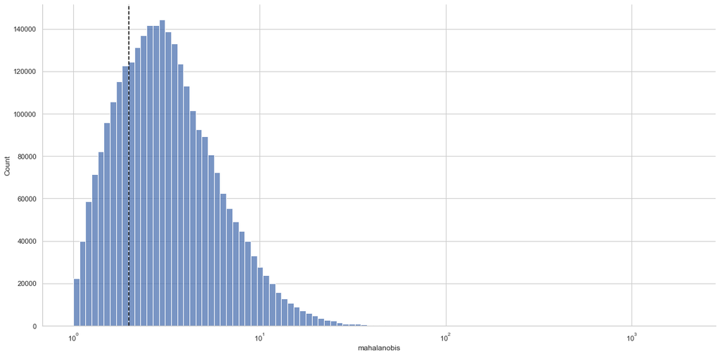

```python
mahalanobis = pd.to_numeric(df['mahalanobis'])

sns.set(style="whitegrid")
sns.displot(mahalanobis+1, bins = 100, log_scale = True,height=8,aspect=2)
median = mahalanobis.median()
plt.axvline(median, color="black", linestyle="--")


plt.show()
```

Necesitamos establecer un límite de la distribución Chi-Cuadrado para dejar fuera de nuestro dataset los valores más alejados de esta. Estimamos el estadístico *p-valor*, que para 4 features sería de 4-1 = 3 grados de libertad. Este valor nos da la probabilidad de que una observación pertenezca a una distribución estándar.

```python
df = df[df['p']>0.01]
```

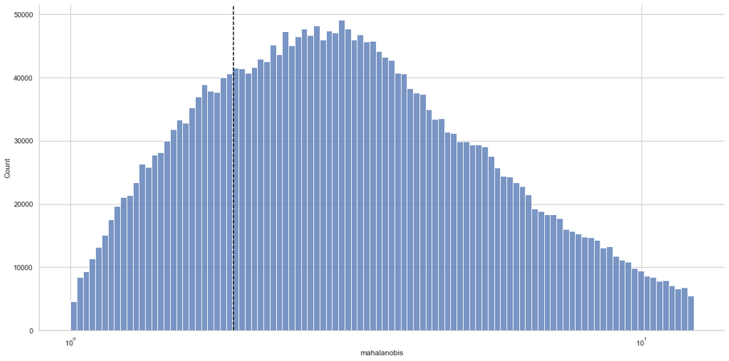

```python
mahalanobis = pd.to_numeric(df['mahalanobis'])

sns.set(style="whitegrid")
sns.displot(mahalanobis+1, bins = 100, log_scale = True,height=8,aspect=2)
median = mahalanobis.median()
plt.axvline(median, color="black", linestyle="--")


plt.show()
```

Eliminamos estas medidas de nuestro dataset, pues no pueden ser usadas para determinar el valor de la variable objetivo.

```python
df = df.drop(['mahalanobis', 'p'],axis=1)
```

```python
df.dtypes
```

```
make                object
model               object
price                int64
year               float64
km                 float64
cv                 float64
make_processed      object
model_processed     object
make_model          object
decade              object
fuel                object
gearshift           object
doors               object
scope               object
n_basic_extra        int64
version_num_dec     object
version_engine      object
version_other       object
n_version_extra      int64
dtype: object
```

```python
df.head()
```

|  | make | model | price | year | km | cv | make_processed | model_processed | make_model | decade | fuel | gearshift | doors | scope | n_basic_extra | version_num_dec | version_engine | version_other | n_version_extra |
| --- | --- | --- | --- | --- | --- | --- | --- | --- | --- | --- | --- | --- | --- | --- | --- | --- | --- | --- | --- |
| 0 | Land Rover | Range Rover Evoque | 22900 | 2012.0 | 113740.0 | 241.0 | land-rover | ran | land-rover-ran | 2010s | gasolina | automatico | 5 puertas | otro | 21 | otro | otro | otro | 4 |
| 1 | Land Rover | Range Rover Evoque | 21900 | 2012.0 | 120770.0 | 241.0 | land-rover | ran | land-rover-ran | 2010s | gasolina | automatico | 3 puertas | otro | 20 | otro | otro | otro | 4 |
| 2 | Land Rover | Range Rover Evoque | 19995 | 2012.0 | 59000.0 | 150.0 | land-rover | ran | land-rover-ran | 2010s | diesel | automatico | 5 puertas | otro | 29 | otro | otro | otro | 4 |
| 3 | Land Rover | Range Rover Sport | 17490 | 2011.0 | 176646.0 | 211.0 | land-rover | ran | land-rover-ran | 2010s | diesel | automatico | 5 puertas | otro | 18 | otro | otro | otro | 3 |
| 4 | Land Rover | Range Rover Sport | 3999 | 2007.0 | 299000.0 | 190.0 | land-rover | ran | land-rover-ran | 2000s | diesel | automatico | 5 puertas | otro | 13 | otro | otro | otro | 1 |

```python
df = pd.read_pickle("df_procesado_final_checkpoint_1.pkl")
```

## Delimitación del rango de actuación

Como hemos expuesto anteriormente, queremos que la funcionalidad del algoritmo no se vea mermada por precios de vehículos que no son usuales en las transacciones que suceden en el mercado de forma diaria.

### Valores cercanos a 0

Algunos vehículos aparecen con precios muy cercanos a 0. Esto puede deberse a varias causas, como que el anunciante no quiere revelar el precio del vehículo, aunque también podría ser un simple fallo de codificación.

Tener un vehículo con precio 0 supone un serio problema para nuestro modelo, pues generará un sesgo en la parametrización de los coeficientes al no haber un patron claro que indique una causalidad lógica para obtener dicho valor.

Teniendo en cuenta que *price* se trata de nuestra variable a predecir, no tiene mucho sentido que nosotros le imputemos un valor para posteriormente entrenar un modelo. Vamos a ver cuantos vehículos hay en nuestro dataframe con un valor por debajo de 100 euros.

### Valores extremos

Tenemos también presencia de vehículos con precios muy altos, correspondientes a vehículos de alta gama como Lamborghini, Ferrari y Porsche.

```python
print("La cantidad de vehículos con precio inferior 100 € es de {}, lo que supone un {} % del total de la muestra.".format(len(df[df['price'] < 100]),round(len(df[df['price'] < 100])*100/len(df),2)))
```

```
La cantidad de vehículos con precio inferior 100 € es de 3873, lo que supone un 0.14 % del total de la muestra.
```

```python
print("La cantidad de vehículos con precio superior a 70.000 € es de {}, lo que supone un {} % del total de la muestra.".format(len(df[df['price'] > 70000]),round(len(df[df['price'] > 70000])*100/len(df),2)))
```

```
La cantidad de vehículos con precio superior a 70.000 € es de 20486, lo que supone un 0.72 % del total de la muestra.
```

Vamos a limitar los precios al rango de 100 a 70.000 euros, lo que abarca más del 99% de nuestro mercado objetivo.

```python
df = df.loc[df['price'] > 100]
df = df.loc[df['price'] < 70000]
```

### Modelos poco comunes

Con el dataset mucho más limpio, podemos considerar las marcas y modelos que serán recogidas para la construcción del algoritmo.

Es conveniente desechar aquellos vehículos cuyas marcas y modelos que no hayan sido recogidas en un mínimo de observaciones, pues generalizar a partir de estos podría ser peligroso.

Las buenas prácticas sugieren que el tamaño mínimo que debería tener una muestra para poder tener algún tipo de significación es **100**. Eliminaremos de nuestro dataframe todos aquellos modelos de vehículo que no cuenten con ese mínimo de observaciones, pues es posible que la muestra recogida sea insuficiente para crear una representación fiable de cada categoría.

```python
# Definimos la variable "count"

df_grouped_marca_modelo = df.groupby(['make_processed', 'model_processed','decade']).agg({'price': ['count']})
df_grouped_marca_modelo.columns = ['count']

df = df.join(df_grouped_marca_modelo, on=['make_processed', 'model_processed','decade'])
```

```python
# Nos quedamos solo con las observaciones cuyo conjunto Marca/Modelo tenga un mínimo de representación.

df = df.loc[df['count'] > 100]
```

Se ha conseguido normalizar considerablemente la distribución de los datos. Las principales variables numéricas se encuentran ahora entre límites razonables.

La variable objetivo sigue una distribución perfectamente geométrica, mientras que la variable *cv* sigue una distribución normal con asimetría positiva.

**Los vehículos previos a la década del año 2000 son pocos, y los anteriores a la década de los años 90 son muy escasos. Hablamos de vehículos con más de 30 años, así que es un razonable límite inferior.**

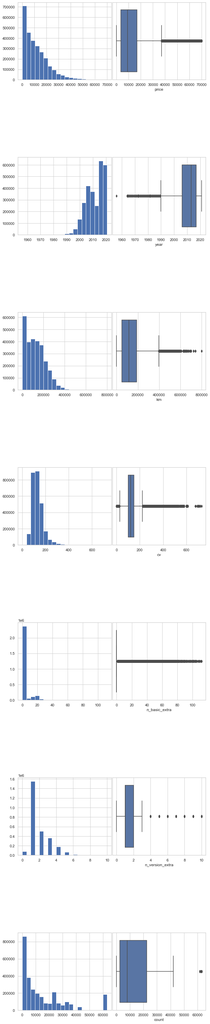

```python
numeric_vals = df.select_dtypes(exclude=['object']).shape[1]

fig, axes = plt.subplots(numeric_vals,2,figsize=(10, 55),gridspec_kw={'wspace': 0.01, 'hspace': 1})
axe = axes.ravel()

for col,i in zip(list(df.dtypes[df.dtypes != 'object'].index), range(0,numeric_vals*2,2)):
    if df[col].dtype != 'object':
        df[col].hist(bins=20, ax=axe[i])
        sns.boxplot(x=df[col], ax=axe[i+1])
```

### Definición del diccionario de modelos

Todos los modelos que quedan en el dataset tienen un número considerable de observaciones y unos datos coherentes. El algoritmo tendrá mucha mas facilidad para tasar estos modelos, así que podemos recogerlos en un diccionario. El usuario podrá ser conocedor de si el programa tiene un mínimo de referencias previas del vehículo que quiere tasar.

Definimos un diccionario que recoja todas las marcas y modelos evaluables por nuestro futuro algoritmo.

Para ello, usamos las variables *make* y *model* sin tratar, que recogen la información completa de nuestra gama de vehículos.

```python
df_included_make_models = df[['make_processed','decade', 'model']]
df_included_make_models
```

|  | make_processed | decade | model |
| --- | --- | --- | --- |
| 0 | land-rover | 2010s | Range Rover Evoque |
| 1 | land-rover | 2010s | Range Rover Evoque |
| 2 | land-rover | 2010s | Range Rover Evoque |
| 3 | land-rover | 2010s | Range Rover Sport |
| 4 | land-rover | 2000s | Range Rover Sport |
| ... | ... | ... | ... |
| 3013658 | land-rover | 2010s | Range Rover Evoque |
| 3013659 | land-rover | 2010s | Range Rover Evoque |
| 3013660 | land-rover | 2010s | Range Rover Evoque |
| 3013661 | land-rover | 2010s | Range Rover Evoque |
| 3013662 | land-rover | 2010s | Range Rover Evoque |

2767166 rows × 3 columns

Eliminando los valores duplicados nos quedamos con todas las combinaciones existentes de *make* y *model*.

```python
df_included_make_models = df_included_make_models.drop_duplicates(keep='first', inplace=False)
df_included_make_models
```

|  | make_processed | decade | model |
| --- | --- | --- | --- |
| 0 | land-rover | 2010s | Range Rover Evoque |
| 3 | land-rover | 2010s | Range Rover Sport |
| 4 | land-rover | 2000s | Range Rover Sport |
| 8 | bmw | 2010s | X1 |
| 20 | alfa-romeo | 2000s | 147 |
| ... | ... | ... | ... |
| 2929260 | fiat | 90s | Panorama |
| 2972887 | aston-martin | 2000s | Vanquish |
| 2976954 | toyota | 2010s | Avensis Verso |
| 2981692 | mini | 2020s | Cooper SD |
| 3011940 | kia | 2020s | ProCeed / pro_cee'd |

2349 rows × 3 columns

Transformamos la información en formato pandas a diccionario.

```python
from collections import defaultdict
included_models = defaultdict(list)
for x,y, j in zip(df_included_make_models.make_processed,df_included_make_models.decade,df_included_make_models.model):
    included_models[(x,y)].append(j)

included_models = dict(included_models)
included_models.keys()
```

```
dict_keys([('land-rover', '2010s'), ('land-rover', '2000s'), ('bmw', '2010s'), ('alfa-romeo', '2000s'), ('ford', '90s'), ('ford', '2010s'), ('ford', '2000s'), ('ford', '2020s'), ('audi', '2010s'), ('audi', '2000s'), ('bmw', '2020s'), ('bentley', '2000s'), ('bmw', '2000s'), ('bmw', '90s'), ('chevrole…
```

```python
import pickle

with open('included_models.p', 'wb') as im:
    pickle.dump(included_models, im, protocol=pickle.HIGHEST_PROTOCOL)
```

```python
included_models[('seat', '90s')]
```

```
['Toledo',
 'Ibiza',
 'Marbella',
 'Inca',
 'CÓRDOBA',
 'Arosa',
 'Alhambra',
 'Arona',
 'Cordoba']
```

## Reducción de variables categóricas

Hemos reducido significativamente la cantidad de marcas/modelos de vehículo en nuestro dataset, pero seguimos teniendo 700. Esto supone un gran esfuerzo a nivel computacional, pues supone tener que estimar 700 coeficientes distintos para una única variable, sin contar las posibles interacciones.

```python
categorical_cols = list(df.select_dtypes(include=['object']).columns)
```

```python
categorical_cols

for col in categorical_cols:
    df[col] = df[col].astype('object')

for col in categorical_cols:
    print(col)
    print(str(len(df[col].unique()))+'\n')
```

```
make
58

model
1181

make_processed
55

model_processed
583

make_model
701

decade
7

fuel
3

gearshift
3

doors
5

scope
3

version_num_dec
8

version_engine
9

version_other
5
```

Tener esta segmentación tan específica de marca/modelo es innecesario y computacionalmente muy costoso. En la mayoría de casos, no proporcionan información adicional para la estimación de la variable objetivo. Existen modelos de vehículo diferentes con prestaciones prácticamente indénticas.

Creamos una nueva feature que agrupe los vehículos de gama similar. Esta agrupación se debe llevar a cabo al mayor nivel de segmentación posible (marca, modelo y década), ya que dentro de algunas marcas podemos encontrar vehículos de gamas muy dispersas. Un ejemplo claro de esto son el **Ford Fiesta** y el **Ford Mustang GT**.

Como la distribución de precio es muy distinta en los distintos años, crearemos un bucle que:

- Definirá unos rangos de precio en base a los cuantiles 90, 75, 60, 45, 30, 15 y el mínimo, para cada década.
- Asignará cada vehículo a uno de los rangos en función del precio medio de su marca/modelo/década.

```python
list(df['decade'].unique())
```

```
['2010s', '2000s', '90s', '2020s', '80s', '70s', 'Anterior a 1970']
```

```python
df['vehicle_range'] = ''
year_ranges = ['Anterior a 1970','70s','80s','90s','2000s','2010s','2020s']
price_quantiles = [0.9,0.75,0.6,0.45,0.3,0.15,0]

for decade in year_ranges:
    price_ranges = []
    for quantile in price_quantiles:
        price_ranges.append(int(df.loc[df['decade']==decade,'price'].quantile(quantile)))
    print("\nPrecios de segmentación de rango para los vehículos de la década de los {}:".format(decade))
    for i in range(len(price_ranges)):
        print("Modelos de vehículo dentro del rango {}: Precio medio de {} € como mínimo.".format(i+1,price_ranges[i]))
    models = list(df.loc[df['decade']==decade,'make_model'].unique())
    model_count = len(models)

    for model in models:
        mean_price = df.loc[(df['decade']==decade)&(df['make_model']==model),'price'].mean()
        position = next(x for x in price_ranges if x < mean_price)
        vehicle_range = price_ranges.index(position)
        df.loc[(df['decade']==decade)&(df['make_model']==model),'vehicle_range'] = 'vehicle_range_' + str(vehicle_range+1)
```

```
Precios de segmentación de rango para los vehículos de la década de los Anterior a 1970:
Modelos de vehículo dentro del rango 1: Precio medio de 55000 € como mínimo.
Modelos de vehículo dentro del rango 2: Precio medio de 44650 € como mínimo.
Modelos de vehículo dentro del rango 3: Precio medio de 39500 € como mínimo.
Modelos de vehículo dentro del rango 4: Precio medio de 33800 € como mínimo.
Modelos de vehículo dentro del rango 5: Precio medio de 27649 € como mínimo.
Modelos de vehículo dentro del rango 6: Precio medio de 20000 € como mínimo.
Modelos de vehículo dentro del rango 7: Precio medio de 400 € como mínimo.

Precios de segmentación de rango para los vehículos de la década de los 70s:
Modelos de vehículo dentro del rango 1: Precio medio de 9000 € como mínimo.
Modelos de vehículo dentro del rango 2: Precio medio de 6000 € como mínimo.
Modelos de vehículo dentro del rango 3: Precio medio de 4800 € como mínimo.
Modelos de vehículo dentro del rango 4: Precio medio de 3999 € como mínimo.
Modelos de vehículo dentro del rango 5: Precio medio de 3000 € como mínimo.
Modelos de vehículo dentro del rango 6: Precio medio de 2300 € como mínimo.
Modelos de vehículo dentro del rango 7: Precio medio de 250 € como mínimo.

Precios de segmentación de rango para los vehículos de la década de los 80s:
Modelos de vehículo dentro del rango 1: Precio medio de 10465 € como mínimo.
Modelos de vehículo dentro del rango 2: Precio medio de 6000 € como mínimo.
Modelos de vehículo dentro del rango 3: Precio medio de 4000 € como mínimo.
Modelos de vehículo dentro del rango 4: Precio medio de 2800 € como mínimo.
Modelos de vehículo dentro del rango 5: Precio medio de 1790 € como mínimo.
Modelos de vehículo dentro del rango 6: Precio medio de 1000 € como mínimo.
Modelos de vehículo dentro del rango 7: Precio medio de 225 € como mínimo.

Precios de segmentación de rango para los vehículos de la década de los 90s:
Modelos de vehículo dentro del rango 1: Precio medio de 5000 € como mínimo.
Modelos de vehículo dentro del rango 2: Precio medio de 2799 € como mínimo.
Modelos de vehículo dentro del rango 3: Precio medio de 1750 € como mínimo.
Modelos de vehículo dentro del rango 4: Precio medio de 1200 € como mínimo.
Modelos de vehículo dentro del rango 5: Precio medio de 950 € como mínimo.
Modelos de vehículo dentro del rango 6: Precio medio de 690 € como mínimo.
Modelos de vehículo dentro del rango 7: Precio medio de 120 € como mínimo.

Precios de segmentación de rango para los vehículos de la década de los 2000s:
Modelos de vehículo dentro del rango 1: Precio medio de 8200 € como mínimo.
Modelos de vehículo dentro del rango 2: Precio medio de 5000 € como mínimo.
Modelos de vehículo dentro del rango 3: Precio medio de 3700 € como mínimo.
Modelos de vehículo dentro del rango 4: Precio medio de 2800 € como mínimo.
Modelos de vehículo dentro del rango 5: Precio medio de 2000 € como mínimo.
Modelos de vehículo dentro del rango 6: Precio medio de 1450 € como mínimo.
Modelos de vehículo dentro del rango 7: Precio medio de 120 € como mínimo.

Precios de segmentación de rango para los vehículos de la década de los 2010s:
Modelos de vehículo dentro del rango 1: Precio medio de 27990 € como mínimo.
Modelos de vehículo dentro del rango 2: Precio medio de 19900 € como mínimo.
Modelos de vehículo dentro del rango 3: Precio medio de 15950 € como mínimo.
Modelos de vehículo dentro del rango 4: Precio medio de 12900 € como mínimo.
Modelos de vehículo dentro del rango 5: Precio medio de 9999 € como mínimo.
Modelos de vehículo dentro del rango 6: Precio medio de 7500 € como mínimo.
Modelos de vehículo dentro del rango 7: Precio medio de 156 € como mínimo.

Precios de segmentación de rango para los vehículos de la década de los 2020s:
Modelos de vehículo dentro del rango 1: Precio medio de 37990 € como mínimo.
Modelos de vehículo dentro del rango 2: Precio medio de 29500 € como mínimo.
Modelos de vehículo dentro del rango 3: Precio medio de 24800 € como mínimo.
Modelos de vehículo dentro del rango 4: Precio medio de 21100 € como mínimo.
Modelos de vehículo dentro del rango 5: Precio medio de 18194 € como mínimo.
Modelos de vehículo dentro del rango 6: Precio medio de 15200 € como mínimo.
Modelos de vehículo dentro del rango 7: Precio medio de 219 € como mínimo.
```

Desde la década de los 90 hacia atrás, la tendencia de precio se revierte. En estos casos muchos vehículos empiezan a adquirir valor como antiguedades y por ello su precio es mayor.

Para poder asignar correctamente la gama a un vehículo determinado por el usuario en el momento de la tasación, necesitamos almacenar esta información.

```python
model_generic = df[['make_processed','model_processed','decade','vehicle_range']].drop_duplicates(keep='first', inplace=False)
```

```python
from collections import defaultdict
make_model_to_range = defaultdict(list)
for x,y,z, j in zip(model_generic.make_processed,model_generic.model_processed,model_generic.decade,model_generic.vehicle_range):
    make_model_to_range[(x,y,z)].append(j)

make_model_to_range = dict(make_model_to_range)
make_model_to_range.keys()
```

```
dict_keys([('land-rover', 'ran', '2010s'), ('land-rover', 'ran', '2000s'), ('bmw', 'x1', '2010s'), ('alfa-romeo', '147', '2000s'), ('ford', 'esc', '90s'), ('ford', 'tou', '2010s'), ('ford', 'tou', '2000s'), ('ford', 'tra', '2010s'), ('ford', 'tra', '2000s'), ('ford', 'pum', '2020s'), ('audi', 'a1', …
```

```python
make_model_to_range[('seat','ibi','2010s')]
```

```
['vehicle_range_6']
```

```python
with open('make_model_to_range.p', 'wb') as mmtr:
    pickle.dump(make_model_to_range, mmtr, protocol=pickle.HIGHEST_PROTOCOL)
```

También almacenamos la mediana de *cv* por rango y década, para poder estimar un rango de precios cuando el modelo del vehículo no es conocido.

```python
df_range_estimator = df.groupby(['vehicle_range', 'decade']).agg({'cv': ['median']})
df_range_estimator.columns = ['median_cv']
df_range_estimator.reset_index(inplace=True)
```

```python
df_range_estimator.to_pickle("df_range_estimator.pkl")
```

Con la información salvaguardada, podemos eliminar todas las variables referentes a modelos de vehículo del dataset.

```python
df = df.drop(['make','model','make_processed','model_processed','make_model','count'], axis=1)
```

Reordenamos las columnas para mayor comodidad.

```python
cols = list(df.columns)
cols = [cols[0]]+[cols[-1]]+cols[1:-1]

df = df[cols]
```

```python
df.head()
```

|  | price | vehicle_range | year | km | cv | decade | fuel | gearshift | doors | scope | n_basic_extra | version_num_dec | version_engine | version_other | n_version_extra |
| --- | --- | --- | --- | --- | --- | --- | --- | --- | --- | --- | --- | --- | --- | --- | --- |
| 0 | 22900 | vehicle_range_1 | 2012.0 | 113740.0 | 241.0 | 2010s | gasolina | automatico | 5 puertas | otro | 21 | otro | otro | otro | 4 |
| 1 | 21900 | vehicle_range_1 | 2012.0 | 120770.0 | 241.0 | 2010s | gasolina | automatico | 3 puertas | otro | 20 | otro | otro | otro | 4 |
| 2 | 19995 | vehicle_range_1 | 2012.0 | 59000.0 | 150.0 | 2010s | diesel | automatico | 5 puertas | otro | 29 | otro | otro | otro | 4 |
| 3 | 17490 | vehicle_range_1 | 2011.0 | 176646.0 | 211.0 | 2010s | diesel | automatico | 5 puertas | otro | 18 | otro | otro | otro | 3 |
| 4 | 3999 | vehicle_range_1 | 2007.0 | 299000.0 | 190.0 | 2000s | diesel | automatico | 5 puertas | otro | 13 | otro | otro | otro | 1 |

Representando la distribución de precios para cada rango de vehículos en una decada determinada, podemos comprobar que la nueva feature discrimina de forma efectiva.

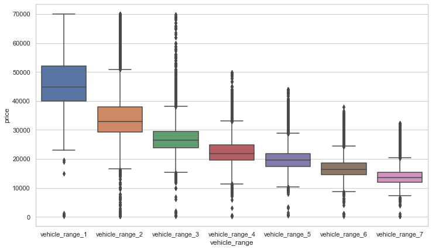

```python
fig, ax = plt.subplots(figsize=(12, 7))

sns.boxplot(data=df[df['decade']=='2020s'],
            x='vehicle_range', y='price', order=[('vehicle_range_'+str(x))for x in range(1,8)])#,showfliers = False)
plt.ylabel = 'Vehicle Range'
plt.show()
```

Podemos de igual manera ver como de discriminantes són algunas de las features creadas respecto a la variable objetivo.

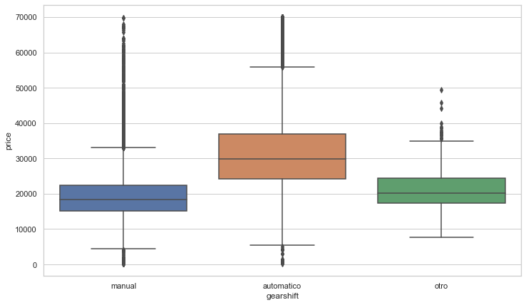

```python
fig, ax = plt.subplots(figsize=(12, 7))

sns.boxplot(data=df[df['decade']=='2020s'],
            x='gearshift', y='price')#,showfliers = False)
plt.ylabel = 'Vehicle Range'
plt.show()
```

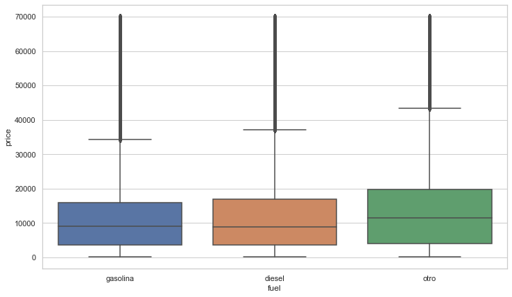

```python
fig, ax = plt.subplots(figsize=(12, 7))

sns.boxplot(data=df,
            x='fuel', y='price')#,showfliers = False)
plt.ylabel = 'Vehicle Range'
plt.show()
```

### Feature Encoding

Algunos modelos trabajan con datasets cuyas variables son enteramente numéricas. Sin embargo, algoritmos como el **CatBoost** indican expresamente en su [documentación](https://catboost.ai/docs/features/categorical-features.html) que no deben aplicarse técnicas de transformación sobre las variables categóricas, pues podría afectar de forma negativa a los resultados de la predicción.

Vamos a realizar las transformaciones pertinentes sobre las variables categóricas almacenando la información en un nuevo dataset que llamaremos *dataset_numeric*. Conservaremos ambos y usaremos el más adecuado a cada una de las técnicas de Machine Learning.

Algunas variables categóricas son ordenables:

- *Vehicle_range_1* es superior en calidad a *Vehicle_range_2*, y así sucesivamente.

Otras no pueden ser ordenadas de ningún modo:

- El combustible puede ser Gasolina, Diesel u otro.

Podemos recodificar las variables categóricas no ordinales como *dummies*, haciendo que tomen valores de 0 y 1.

```python
categorical_non_ordinal = ['fuel','gearshift','scope','version_engine','version_other']
```

```python
df_dummies = pd.get_dummies(df[categorical_non_ordinal])

df_dummies = df_dummies.drop(['fuel_otro','gearshift_otro','scope_otro',
                              'version_engine_otro','version_other_otro'], axis=1)

df_numeric = pd.concat([df[numerical_cols], df_dummies], axis = 1, ignore_index=True)

df_numeric.columns = list(df[numerical_cols].columns)+list(df_dummies.columns)
```

Eliminamos la columna **other** para cada variable dummy, para evitar tener features redundantes con VIF infinito. Podríamos hacerlo automáticamente con el parámetro *drop_first=True*, pero no sería posible elegir las categorías que quedan fuera del dataset.

Recodificamos las variables categóricas ordinales. No usamos la librería de *sklearn* *Label Encoder*, ya que el índice se establece por orden alfabético, y no es lo que queremos.

```python
categorical_ordinal = ['vehicle_range','decade','doors','version_num_dec']
```

```python
for feature in categorical_ordinal:
    print(df[feature].unique())
```

```
['vehicle_range_1' 'vehicle_range_2' 'vehicle_range_5' 'vehicle_range_4'
 'vehicle_range_6' 'vehicle_range_3' 'vehicle_range_7']
['2010s' '2000s' '90s' '2020s' '80s' '70s' 'Anterior a 1970']
['5 puertas' '3 puertas' 'otro' '4 puertas' '2 puertas']
['otro' '2.0' '1.5' '1.0' '1.6' '1.4' '1.2' '1.9']
```

```python
df_numeric['vehicle_range_num'] = df['vehicle_range'].apply(lambda x: ['vehicle_range_1','vehicle_range_2','vehicle_range_3',
                                                                       'vehicle_range_4','vehicle_range_5','vehicle_range_6',
                                                                       'vehicle_range_7'].index(x))

df_numeric['decade_num'] = df['decade'].apply(lambda x: ['Anterior a 1970','70s','80s','90s','2000s','2010s','2020s'].index(x))
df_numeric['doors_num'] = df['doors'].apply(lambda x: ['otro','2 puertas','3 puertas','4 puertas','5 puertas'].index(x))
df_numeric['version_num_dec_num'] = df['version_num_dec'].apply(lambda x: ['otro','1.0','1.2','1.4','1.5','1.6','1.9','2.0'].index(x))
```

### Mejoras descartadas

La distribución y naturaleza de la variable *price*, con una fuerte asimetría positiva, sugería que una transformación logarítmica podría funcionar bien en el modelo. Sin embargo, en pruebas realizadas durante el trabajo se ha observado que el resultado obtenido era ligeramente peor, con lo cual no aportaba nada.

Lo mismo ocurre con las variables *cv* y *km*, todas con una distribución similar.

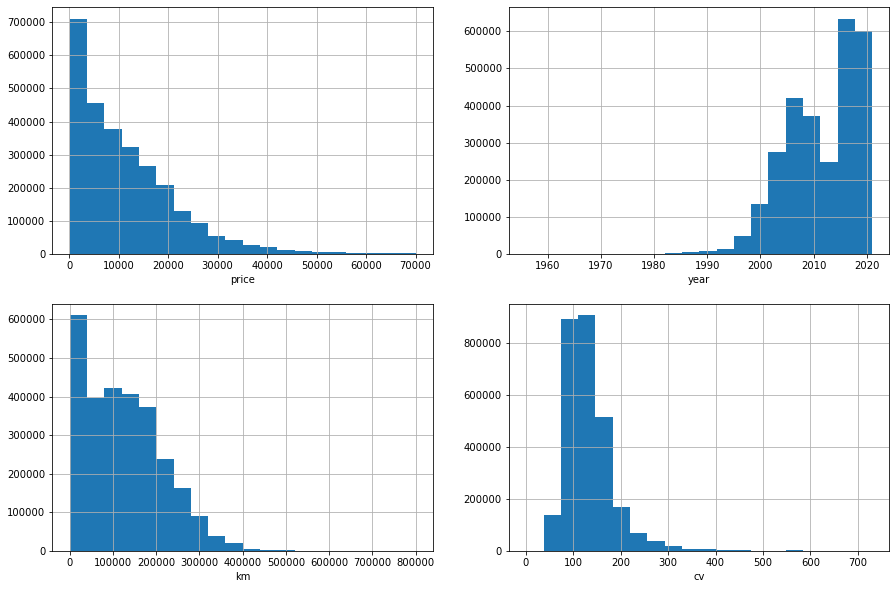

```python
numeric_vals = df.select_dtypes(exclude=['object']).shape[1]

fig, axes = plt.subplots(2,2,figsize=(15, 10))
axe = axes.ravel()

for col,i,ax in zip(list(df.dtypes[df.dtypes != 'object'].index), range(0,numeric_vals*2),axe):
    if df[col].dtype != 'object':
        df[col].hist(bins=20, ax=axe[i])
        ax.set_xlabel(col)
```

## Correlación y Multiconealidad

Antes de crear los modelos de Machine Learning es conveniente tratar la posible multicolinealidad del modelo.

Podemos estudiar las correlaciones entre las distintas variables de nuestro dataset empleando la técnica estadística correspondiente acorde a su tipología:

- Entre variables numéricas: Coeficiente de correlación de Pearson.
- Entre variables categóricas: V de Cramer.
- Entre variables numéricas y categóricas: Razón de correlación η.

Creamos dos listas para las dos tipologías de variable para poder trabajar con mayor comodidad.

```python
categorical_cols = list(df.select_dtypes(include=['object']).columns)
numerical_cols = list(df.select_dtypes(exclude=['object']).columns)
```

### Coeficiente de correlación de Pearson

El coeficiente de correlación de Pearson mide la dependencia lineal entre dos variables numéricas o cuantitativas. Los valores que puede tomar van de -1 hasta 1, donde:

- Cuando el coeficiente tiende a -1, la correlación es inversa o negativa.
- Cuando el coeficiente tiende a 1, la correlación es proporcional o positiva.
- Cuando el coeficiente tiende a 0, la correlación es nula.

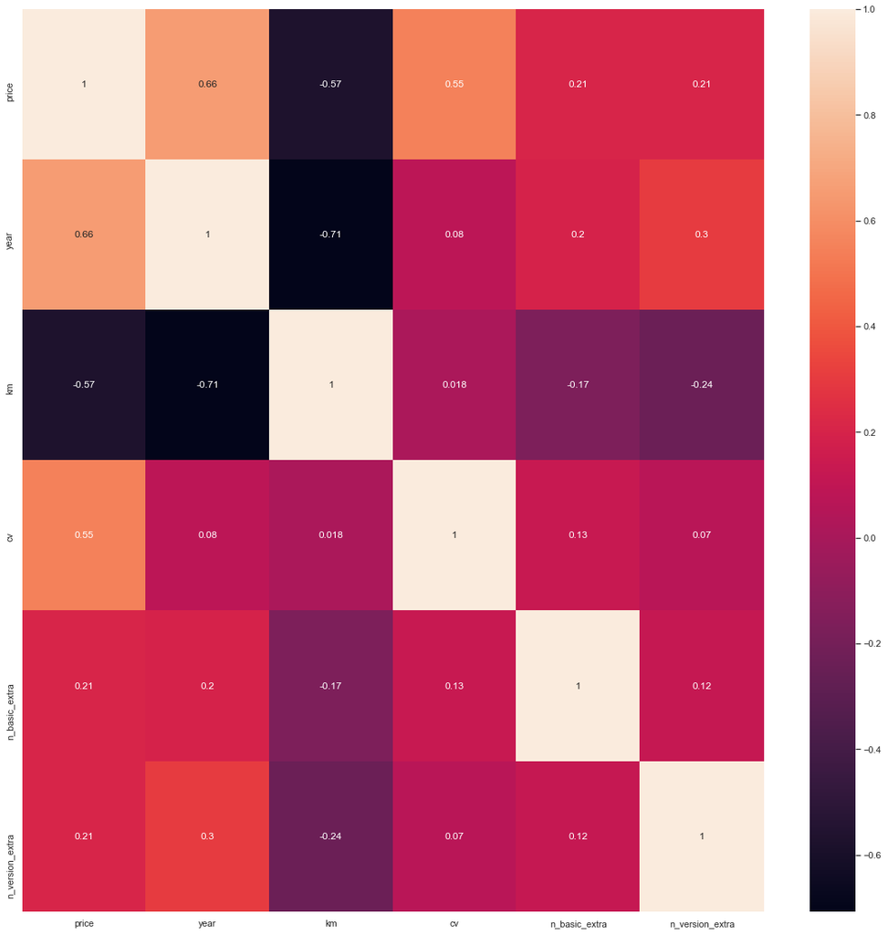

```python
correlations = df[numerical_cols].corr()
f, ax = plt.subplots(figsize = (20,20))
sns.heatmap(correlations, annot = True)
```

Hay una fuerte correlación negativa entre el año de matriculación de un vehículo y los km recorridos. Cuanto más antiguo es el vehículo, más rodaje tiene.

También se observa una correlación positiva entre los CV, el año de matriculación y el precio. Una mayor potencia y una fecha de matriculación más reciente contribuyen a un mayor precio del vehículo.

Las features referentes al número de accesorios y tags no son muy significativas, y su cuantificación a la hora de tasar un vehículo es muy relativa, ya que algunos anuncios contabilizan elementos prácticamente universales como el aire acondicionado. Para evitar complicar el modelo de manera innecesaria, las eliminamos de nuestro dataset.

```python
df = df.drop(['n_version_extra','n_basic_extra'],axis=1)
numerical_cols.remove('n_version_extra')
numerical_cols.remove('n_basic_extra')
```

### V de Crámer

El coeficiente V de Cramér es una medida del tamaño del efecto para la prueba chi-cuadrado de la independencia. En él se mide la forma en que están asociadas dos variables nominales o categóricas. La relación se mide siempre entre 0 y 1, donde 0 indica correlación nula y 1 indica correlación perfecta.

Recorremos de forma iterativa las variables categóricas de nuestro dataset y estimamos el estadístico V de Crámer para cada par de features.

```python
import scipy.stats as ss

def cramers_corrected_stat(confusion_matrix):
    """ calculate Cramers V statistic for categorial-categorial association.
        uses correction from Bergsma and Wicher,
        Journal of the Korean Statistical Society 42 (2013): 323-328
    """
    chi2 = ss.chi2_contingency(confusion_matrix)[0]
    n = confusion_matrix.sum().sum()
    phi2 = chi2/n
    r,k = confusion_matrix.shape
    phi2corr = max(0, phi2 - ((k-1)*(r-1))/(n-1))
    rcorr = r - ((r-1)**2)/(n-1)
    kcorr = k - ((k-1)**2)/(n-1)
    return np.sqrt(phi2corr / min( (kcorr-1), (rcorr-1)))
```

```python
feature_1 = []
feature_2 = []
v_coef = []


for feature in categorical_cols:
    cols = categorical_cols.copy()
    cols.remove(feature)
    for col in cols:
        confusion_matrix = pd.crosstab(df[feature], df[col])
        feature_1.append(feature)
        feature_2.append(col)
        v_coef.append(cramers_corrected_stat(confusion_matrix))

v_cramer_df = pd.DataFrame({'Feature 1': feature_1,
                            'Feature 2': feature_2,
                            'Cramér\'s V': v_coef})

v_cramer_df = v_cramer_df.drop_duplicates(subset='Cramér\'s V', keep='first')
```

Ordenamos los coeficientes por fuerza de correlación.

```python
v_cramer_df.sort_values(by='Cramér\'s V', ascending=False).head(10)
```

|  | Feature 1 | Feature 2 | Cramér's V |
| --- | --- | --- | --- |
| 54 | version_num_dec | version_engine | 0.324785 |
| 2 | vehicle_range | gearshift | 0.322834 |
| 22 | fuel | version_engine | 0.290485 |
| 20 | fuel | scope | 0.275713 |
| 21 | fuel | version_num_dec | 0.268756 |
| 12 | decade | scope | 0.266559 |
| 27 | gearshift | doors | 0.218515 |
| 63 | version_engine | version_other | 0.209743 |
| 71 | version_other | version_engine | 0.209743 |
| 53 | version_num_dec | scope | 0.185907 |

Existe cierta relación entre features como *version_num_dec* y *version_motor* o *vehicle_range* y *gearshift*, pero ninguna está estrechamente relacionada. La correlación entre variables categóricas es baja.

### Razón de correlación η

La razón de correlación η cuantifica el grado deconcentración de la distribución de una variable numérica y una variable categórica en torno a la correspondiente curva de regresión. Al igual que con el estadístico V de Crámer, la relación se mide entre 0 y 1 para indicar correlación nula o correlación perfecta, respectivamente.

```python
def eta_coefficient(categories, values):
    cat = np.unique(categories, return_inverse=True)[1]
    values = np.array(values)

    ssw = 0
    ssb = 0
    for i in np.unique(cat):
        subgroup = values[np.argwhere(cat == i).flatten()]
        ssw += np.sum((subgroup-np.mean(subgroup))**2)
        ssb += len(subgroup)*(np.mean(subgroup)-np.mean(values))**2

    return (ssb / (ssb + ssw))**.5
```

```python
feature_1 = []
feature_2 = []
eta_coef = []


for feature in categorical_cols:
    cols = categorical_cols.copy()
    cols = list(df.select_dtypes(exclude=['object']).columns)
    for col in cols:
        coef = eta_coefficient(df[feature], df[col])
        feature_1.append(feature)
        feature_2.append(col)
        eta_coef.append(coef)

eta_df = pd.DataFrame({'Feature 1': feature_1,
                       'Feature 2': feature_2,
                       'Eta Coefficient': eta_coef
                      })
```

Ordenamos los coeficientes por fuerza de correlación.

```python
eta_df.sort_values(by='Eta Coefficient', ascending=False).head(10)
```

|  | Feature 1 | Feature 2 | Eta Coefficient |
| --- | --- | --- | --- |
| 5 | decade | year | 0.927674 |
| 3 | vehicle_range | cv | 0.712239 |
| 6 | decade | km | 0.682958 |
| 4 | decade | price | 0.639239 |
| 0 | vehicle_range | price | 0.529011 |
| 12 | gearshift | price | 0.520550 |
| 15 | gearshift | cv | 0.503724 |
| 21 | scope | year | 0.399403 |
| 25 | version_num_dec | year | 0.314939 |
| 22 | scope | km | 0.314770 |

Existe una correlación muy alta entre las variables *decade* y *year*, como es lógico, al ser la primera una tramificación de la segunda. Tendremos que elegir una de las dos variables para evitar tener una alta colinealidad en nuestro modelo. Además, al estar estrechamente relacionadas, *decade* tiene una fuerte correlación con las variables *km* y *price*.

Existe también una fuerte relación entre *vehicle_range* y *cv*. Tiene bastante sentido, ya que los vehículos de alta gama tienden a tener unas potencias bastante superiores.

La variable *gearshift* tiene una notable correlación con la variable objetivo.

### Respuesta frente a la variable objetivo

Con todas las variables en formato numérico, podemos observar de forma conjunta la correlación de cada una de las features de nuestro dataset con la variable objetivo.

```python
corr = abs(df_numeric.corr())
corr[['price']].sort_values(by = 'price',ascending = False).style.background_gradient()
```

|  | price |
| --- | --- |
| price | 1.000000 |
| year | 0.656868 |
| decade_num | 0.607527 |
| km | 0.568451 |
| cv | 0.550054 |
| gearshift_manual | 0.519985 |
| gearshift_automatico | 0.519724 |
| vehicle_range_num | 0.463412 |
| scope_particular | 0.260949 |
| scope_profesional | 0.258569 |
| version_engine_d | 0.187966 |
| version_engine_tdi | 0.109940 |
| version_engine_hdi | 0.087626 |
| doors_num | 0.071446 |
| version_engine_tsi | 0.062750 |
| version_other_4x2 | 0.055724 |
| version_other_advance | 0.051342 |
| version_num_dec_num | 0.046053 |
| version_engine_s&s | 0.046009 |
| version_other_sport | 0.037077 |
| fuel_gasolina | 0.036007 |
| version_engine_tdci | 0.027300 |
| version_engine_bluehdi | 0.019961 |
| version_other_style | 0.017873 |
| fuel_diesel | 0.007425 |
| version_engine_dci | 0.005856 |

La feature *year* tiene una mejor respuesta frente a la variable objetivo que su versión tramificada *decade*.

```python
df_numeric = df_numeric.drop(['decade_num'], axis=1)
df = df.drop(['decade'], axis=1)
categorical_cols.remove('decade')
```

### Variance Inflation Factor

El Factor de inflación de la varianza o Variance Inflation Factor, más conocido como VIF, es una medida de la cantidad de multicolinearidad en un conjunto de variables. Este coeficiente permite identificar el grado de dependencia entre dos variables numéricas.

Es importante cerciorarse de que no existan variables con una alta relación de dependencia en el dataset. Pese a que muchas librerías de Machine Learning pueden trabajar bien pese a la existencia de colinealidad, es mejor tratarla antes de modelizar.

La función que sigue estima el VIF para cada variable y elimina de forma iterativa aquellas features cuyo factor de inflación es superior.

```python
## Hint: An infinite VIF value indicates that the corresponding variable may be expressed exactly by a linear combination of other variables (which show an infinite VIF as well).
## http://www.imagelab.at/help/vif_descriptors.htm

from sklearn.linear_model import LinearRegression

def vifLimit(df, vif_threshold = 5):
    df_vif = df.copy(deep = True)
    features = list(df_vif.columns)
    features.remove('price')
    df_vif = df_vif[features]
    vif_dict = {}

    for i in range(len(features)):
        var = features[i]
        fet = features[:]
        fet.remove(var)

        x = df_vif[fet]
        y = df[var]

        model = LinearRegression()
        model.fit(x, y)

        vif = 1 / (1 - model.score(x, y))
        vif_dict[var] = vif

        print ('El valor del VIF para la variable', var, 'es:', vif)
        max_vif_var = max(vif_dict, key=vif_dict.get)

    print ('El valor de VIF más alto es de:', vif_dict[max_vif_var], 'y corresponde a la variable', max_vif_var)
    df = df.drop([max_vif_var], axis=1)
    if vif_dict[max_vif_var] > vif_threshold:
        print ('\nVariable',max_vif_var,'eliminada del DataFrame por superar el límite de VIF. \nSiguiente ejecución:\n')
        df = vifLimit(df, vif_threshold = vif_threshold)
    return df
```

```python
df_numeric = vifLimit(df_numeric)
```

```
El valor del VIF para la variable year es: 2.5295965093197013
El valor del VIF para la variable km es: 2.3393283899249258
El valor del VIF para la variable cv es: 2.020744988309052
El valor del VIF para la variable fuel_diesel es: 3.067149597718428
El valor del VIF para la variable fuel_gasolina es: 3.0147800547373977
El valor del VIF para la variable gearshift_automatico es: 96.39991400513706
El valor del VIF para la variable gearshift_manual es: 96.57381251190331
El valor del VIF para la variable scope_particular es: 1.7006043266157216
El valor del VIF para la variable scope_profesional es: 1.6799130756531235
El valor del VIF para la variable version_engine_bluehdi es: 1.0904060928273374
El valor del VIF para la variable version_engine_d es: 1.1090358595257435
El valor del VIF para la variable version_engine_dci es: 1.103242860251397
El valor del VIF para la variable version_engine_hdi es: 1.138043714719612
El valor del VIF para la variable version_engine_s&s es: 1.06672509365285
El valor del VIF para la variable version_engine_tdci es: 1.1266387012711911
El valor del VIF para la variable version_engine_tdi es: 1.744558410613062
El valor del VIF para la variable version_engine_tsi es: 1.1189910658915692
El valor del VIF para la variable version_other_4x2 es: 1.0715810538542723
El valor del VIF para la variable version_other_advance es: 1.1151588437446949
El valor del VIF para la variable version_other_sport es: 1.0580198689924998
El valor del VIF para la variable version_other_style es: 1.042670609899657
El valor del VIF para la variable vehicle_range_num es: 2.0083955458796185
El valor del VIF para la variable doors_num es: 1.1404125078546827
El valor del VIF para la variable version_num_dec_num es: 1.7910792720426452
El valor de VIF más alto es de: 96.57381251190331 y corresponde a la variable gearshift_manual

Variable gearshift_manual eliminada del DataFrame por superar el límite de VIF.
Siguiente ejecución:

El valor del VIF para la variable year es: 2.5277086114418106
El valor del VIF para la variable km es: 2.3389851605693446
El valor del VIF para la variable cv es: 2.0200028175548956
El valor del VIF para la variable fuel_diesel es: 3.062999111652904
El valor del VIF para la variable fuel_gasolina es: 3.010849269680223
El valor del VIF para la variable gearshift_automatico es: 1.5278557068687744
El valor del VIF para la variable scope_particular es: 1.7002008698510047
El valor del VIF para la variable scope_profesional es: 1.6798137747301038
El valor del VIF para la variable version_engine_bluehdi es: 1.0903732981532908
El valor del VIF para la variable version_engine_d es: 1.1089694004500765
El valor del VIF para la variable version_engine_dci es: 1.1032373714667076
El valor del VIF para la variable version_engine_hdi es: 1.1378135003417817
El valor del VIF para la variable version_engine_s&s es: 1.0667250932832724
El valor del VIF para la variable version_engine_tdci es: 1.1266312404427974
El valor del VIF para la variable version_engine_tdi es: 1.7444010748927554
El valor del VIF para la variable version_engine_tsi es: 1.118988483331211
El valor del VIF para la variable version_other_4x2 es: 1.0715776251743987
El valor del VIF para la variable version_other_advance es: 1.1151477933995173
El valor del VIF para la variable version_other_sport es: 1.0580197414658026
El valor del VIF para la variable version_other_style es: 1.0426703739745151
El valor del VIF para la variable vehicle_range_num es: 2.008062596202444
El valor del VIF para la variable doors_num es: 1.1241511491735154
El valor del VIF para la variable version_num_dec_num es: 1.791000355947848
El valor de VIF más alto es de: 3.062999111652904 y corresponde a la variable fuel_diesel
```

Al conocer si un vehículo es automático, se puede deducir al instante que no es manual, y viceversa. Por ello, la correlación entre ambas dummies es muy fuerte y basta con quedarnos con una de ellas.

El resto de variables tienen un VIF muy bajo, lo cual es una buena señal de que no quedan variables redundantes en nuestro dataset.

Guardamos los dataframes finales para no perder el progreso durante la fase de modelización.

```python
df.to_pickle("df_procesado_3.pkl")
df_numeric.to_pickle("df_procesado_3_num.pkl")
```

```python
import pandas as pd
import numpy as np
import matplotlib.pyplot as plt
import seaborn as sns
import unidecode

from tqdm import tqdm
tqdm.pandas()

df = pd.read_pickle("df_procesado_3.pkl")
df_numeric = pd.read_pickle("df_procesado_3_num.pkl")
```

## Fase de modelización

Acabados todos los procesos de limpieza y procesamiento de datos, podemos pasar a la fase de modelización. Dado que nuestro objetivo es predecir el valor de una variable continua, *price*, nos enfrentamos a un problema de regresión.

Existen una gran variedad de algoritmos que podemos utilizar: Desde una regresión lineal a métodos más complejos que implican arboles de decisión. Para nuesto caso, los modelos que vamos a utilizar son los siguientes:

- Regresión lineal
  - Ridge
  - Lasso
- Support Vector Regression (SVR)
- Gradient Boosting
  - XGBoost
  - CatBoost

Antes de entrar en detalle, preparamos las particiones de *Train/Test*. Realizar un *Cross Validation* nos daría una medida más precisa de la calidad del modelo, pero sería computacionalmente muy costoso ya que nuestro dataset tiene un tamaño muy grande. Sin embargo, será precisamente esto lo que nos asegurará que la pérdida de información sea mínima.

Solo se realizará selección de parámetros con *GridSearchCV* para los modelos de Regresión Lineal Lasso y Ridge. Se planteará el código para realizarlo en el resto de modelos.

```python
df_y = df['price']
df_x = df.drop(['price'], axis=1)

df_numeric_y = df_numeric['price']
df_numeric_x = df_numeric.drop(['price'], axis=1)
```

```python
from sklearn.model_selection import train_test_split

X_train, X_test, y_train, y_test = train_test_split(df_x, df_y, test_size = 0.2, random_state=5)

X_numeric_train, X_numeric_test, y_numeric_train, y_numeric_test = train_test_split(df_numeric_x, df_numeric_y, test_size = 0.2, random_state=5)
```

### Regresión Lineal

En una regresión lineal, se busca una relación que permita predecir un valor numérico a partir de uno o varios inputs también numéricos. Como su propio nombre indica, en este tipo de regresión se asume una relación de dependencia lineal entre las features o inputs y la variable objetivo.

La estimación de los coeficientes de un modelo de regresión lineal se determina minimizando la suma de los residuos al cuadrado. Esto es, la diferencia de valor entre cada observación y la función de regresión.

En modelos de regresión lineal complejos, existe el riesgo de que los parámetros se adapten tan bien a los datos de entrenamiento que, para cada pequeña variación en uno de los inputs, la variable objetivo cambie drásticamente. Las features toman una importancia exagerada y esto se traduce que los coeficientes estimados toman valores muy elevados. Este hecho se conoce como Overfitting.

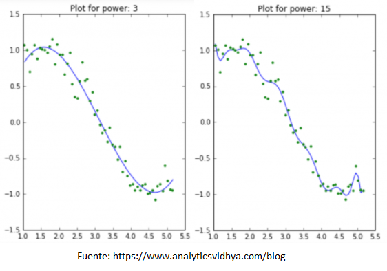

Existen mecanismos de regularización para reducir la varianza y el riesgo de Overfitting, que añaden una penalización a la función de optimización. Esta nueva condición evita que los coeficientes crezcan de manera desproporcionada, pues el incremento que supondría reducir la suma de los residuos se vería anulado por el aumento aun mayor de la penalización en la función de optimización.

#### Ridge

La **Regresión Ridge** plantea esta solución, añadiendo una regularización L2. Esta regularización consiste en un parametro Alfa α que regula la penalización que se añade a la función de optimización de la suma de los cuadrados de los residuos. Cuanto más grande sea este parámetro, mayor será la penalización sobre el tamaño de los coeficientes.

Objective = RSS + α * (sum of square of coefficients)

Es importante estimar un valor de α adecuado. Mientras que atribuir a α el valor 0 hace que la penalización sea nula, un valor demasiado elevado hará que los coeficientes tomen valores muy bajos, reduciendo progresivamente la complejidad del modelo. Esto nos llevaría al caso contrario y también indeseado: Incurririamos en una falta de ajuste del modelo a los datos, también conocida como Underfitting.

Para hallar el valor apropiado de penalización, es necesario comprobar el rendimiento del modelo para distintos valores de α. Para hacer esto, podemos recurrir a la librería *GridSearch* de *Scikit Learn*.

Probaremos distintos valores de α en intervalos de 0.1 desde 0.01 hasta 1. Aplicaremos una normalización sobre las variables input con el parámetro *normalize*= **True**), para facilitar la convergencia de la función objetivo.

Como la función de scoring busca el mayor valor posible, estimaremos la *Raiz del Error Cuadrático Medio* o *RMSE* en valor negativo. Esto se hace así ya que el algoritmo de CV buscará siempre el mayor valor, y en este caso será el error más cercano a 0. Optamos por esta métrica sobre el *Error Absoluto Medio* ya que este último penaliza menos la presencia de valores atípicos.

```python
import numpy as np
from sklearn.metrics import mean_squared_error

from sklearn.linear_model import Ridge
from sklearn.linear_model import RidgeCV
from sklearn.model_selection import RepeatedKFold

ridgecv = RidgeCV(alphas = np.linspace(0.01, 1, 10), scoring = 'neg_mean_squared_error', normalize = True)
ridgecv.fit(X_numeric_train, y_numeric_train)

ridge = Ridge(alpha = ridgecv.alpha_, normalize = True)
ridge.fit(X_numeric_train, y_numeric_train)
print('Valor de Alpha: %.3f' % ridgecv.alpha_)
print('RMSE: %.3f' % np.sqrt(mean_squared_error(y_numeric_test, ridge.predict(X_numeric_test))))
```

```
Valor de Alpha: 0.010
RMSE: 4878.435
```

Podemos realizar una segunda segmentación más específica alrededor del valor hallado, para acotar aun más el valor ideal de α.

```python
ridgecv = RidgeCV(alphas = np.linspace(0.005, 0.015, 10), scoring = 'neg_mean_squared_error', normalize = True)
ridgecv.fit(X_numeric_train, y_numeric_train)

ridge = Ridge(alpha = ridgecv.alpha_, normalize = True)
ridge.fit(X_numeric_train, y_numeric_train)
print('Valor de Alpha: %.3f' % ridgecv.alpha_)
print('RMSE: %.3f' % np.sqrt(mean_squared_error(y_numeric_test, ridge.predict(X_numeric_test))))
```

```
Valor de Alpha: 0.005
RMSE: 4878.270
```

La variación en el RMSE es mínima. Por lo tanto, el RMSE de nuestra regresión Ridge es de 4878,27 con un valor de α muy cecano a 0.

#### Lasso

El modelo de regresión Lasso tiene un planteamiento muy similar a Ridge. La diferencia está en la penalización implementada en la función objetivo, que en este caso es la denominada regularización L1.

LS Obj + α * (sum of absolute value of coefficients)

Mientras que la regularización L2 de Ridge penaliza el incremento de valor de los coeficientes de forma exponencial, la regulariación L1 de la regresión Lasso, lo hace de manera absoluta y lineal. Pese a que el planteamiento parece a priori similar, esta diferencia supone que para valores similares de α, los coeficientes tomen valores muy inferiores a los que tomarían en la regresión Ridge, lo que lleva a un peor ajuste del modelo.

Además, la particularidad de la regresión Lasso frente a Ridge es que los coeficientes pueden tomar valor 0. Es decir, la regresión Lasso puede dejar fuera del modelo aquellas variables que sean menos relevantes.

Vamos a plantear una busqueda del valor óptimo de α de manera muy similar a como hemos hecho en el modelo anterior.

```python
from sklearn.linear_model import Lasso
from sklearn.linear_model import LassoCV
from sklearn.metrics import mean_squared_error

lasso = Lasso(max_iter = 10000, normalize = True)
lassocv = LassoCV(alphas = np.linspace(0.01, 1, 10), cv = 10, max_iter = 100000, normalize = True)
lassocv.fit(df_numeric_x, df_numeric_y)

lasso.set_params(alpha=lassocv.alpha_)
lasso.fit(X_numeric_train, y_numeric_train)
print('Valor de Alpha: %.3f' % lassocv.alpha_)
print('RMSE: %.3f' % np.sqrt(mean_squared_error(y_numeric_test, lasso.predict(X_numeric_test))))
```

```
Valor de Alpha: 0.010
RMSE: 4878.608
```

### Support Vector Regression

El Support Vector Regression, también conocido como SVR surge como variante del módelo de clasificación SVM. En el SVM se genera un hiperplano que separa las distintas clases en el espacio. Este hiperplano es definido como el vector entre los dos puntos más cercanos entre clases, y recibe el nombre de vector soporte.

Cuando el conjunto de datos es demasiado complejo, el SVM proyecta los puntos a un espacio de dimensonalidad superior, consiguiendo dividir los datos en un espacio lineal, tal y como podemos ver en el siguiente ejemplo:

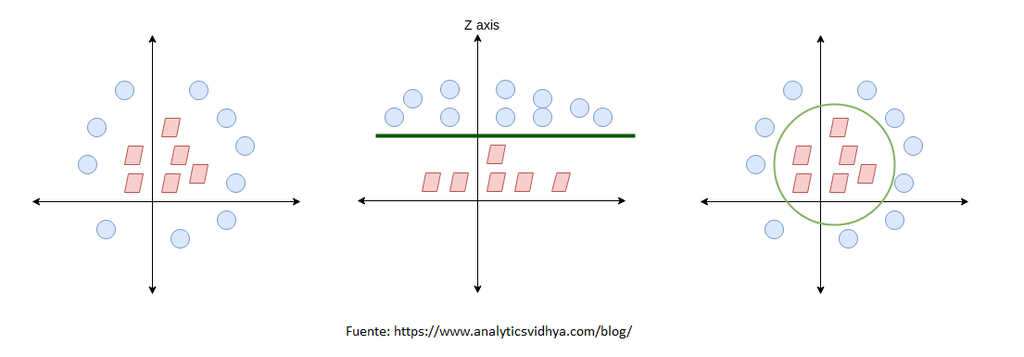

El Support Vector Regression funciona bajo el mismo principio con algunas adaptaciones. En este caso, dado que la variable objetivo es numérica, se establece un margen de tolerancia entorno al vector con el objetivo de minimizar el error. El objetivo es conseguir un hiperplano que contenga el máximo de puntos dentro de los margenes de tolerancia.

Así, cuando el comportamiento de la variable no es lineal, podemos escalar a un nivel más alto en el espacio dimensional para realizar la clasificación de forma correcta.

Desgraciadamente, estimar el modelo de SVR es demasiado costoso a nivel computacional debido al gran tamaño de nuestro dataset, así que no podemos evaluar su funcionamiento. Sin embargo, planteamos el código para su ejecución

Estimariamos el modelo de SVR para nuestro dataset numérico, normalizando las features de entrada. Como kernel, usariamos una *Función de Base Radial* o *rbf*, utilizada comunmente en casuísticas similares. Como siempre, un GridSearch nos permitiría hallar los parámetros idóneos del modelo.

```python
from sklearn.preprocessing import StandardScaler
from sklearn.svm import SVR
sc = StandardScaler()
X_numeric_train_norm = sc.fit_transform(X_numeric_train)

#svr = SVR(kernel = 'rbf')
svr = SVR(kernel = 'linear', verbose=True)
svr.fit(X_numeric_train, y_numeric_train)
```

```
[LibSVM]
```

```python
from sklearn.preprocessing import StandardScaler
from sklearn.svm import SVR
from sklearn.model_selection import GridSearchCV

sc = StandardScaler()
X_numeric_train_norm = sc.fit_transform(X_numeric_train)


param = {'kernel' : ['rbf'],
         'gamma': [1e-4, 1e-3, 0.01, 0.1, 0.2, 0.5, 0.6, 0.9],
         'C': [1, 10, 100, 1000, 10000]}

svr = SVR()

grid_search_svr = GridSearchCV(estimator = svr, param_grid = param, cv = 3, verbose = 2)

grid_search_svr.fit(X_numeric_train, y_numeric_train)
```

```
Fitting 3 folds for each of 40 candidates, totalling 120 fits
```

### Gradient Boosting

En un modelo de Gradient Boosting, el entrenamiento es realizado de manera secuencial. Estos modelos se componen de un conjunto de árboles de decisión entrenados de forma individual, donde cada uno de estos es entrenado con un subconjunto de variables elegidas de manera aleatoria y que permiten generar sus clasificaciones de maneras complementarias. Cada árbol trata de mejorar los errores cometidos en los casos peor clasificados por el anterior, y el resultado final se obtiene a partir de la agregación de las predicciones de cada uno de los árboles.

Esta agregación de árboles con selección de variables aleatorias permite suplir las carencias que sufridas por los modelos compuestos por un único arbol. Estos modelos de deicisión suelen elegir siempre las mismas variables al seguir un proceso secuencial en orden de importancia. Pese a que funcionan bien, su sencillez puede llevar a una exploración del espacio de variables demasiado acotada.

En los modelos de *Regresión Lineal* se suele generar una única ecuación global que aplica a todo el espacio muestral. Esto es insuficiente cuando en los datos existen múltiples predictores que interaccionan de forma compleja y no lineal entre ellos. Los modelos basados en *Random Forest* permiten segmentar el espacio de los predictores, permitiendo un manejo más óptimizado de las interacciones entre features.

Los modelos de Gradient Boosting que vamos a implementar en nuestro proyecto son el XGBoost y el CatBoost. Ambos tienen una estructura de funcionamiento muy similar. Además, los dos algoritmos permiten la implementación de tarjeta gráfica, lo que acelera enormemente el proceso de estimación de los coeficientes.

#### XGBoost

XGBoost requiere de codificación de variables categóricas, de modo que usamos el dataset codificado numéricamente.

Estimaremos los parámetros de forma manual, ya que realizar un *GridSearch* para hallar los mejores parámetros sería computacionalmente muy costos, aunque permitiría obtener el resultado óptimo del modelo.

```python
import xgboost as xgb

params = {
    'objective': 'reg:squarederror',
    'learning_rate': '0.01',
    'colsample_bynode': '0.5',
    'n_estimators': 60000,
    'min_child_weight': 5,
    'tree_method': 'gpu_hist',
    'verbosity': '2'
}

xgboost = xgb.XGBRegressor(**params)
xgboost.fit(X_numeric_train,y_numeric_train)
```

```
XGBRegressor(base_score=0.5, booster='gbtree', colsample_bylevel=1,
             colsample_bynode='0.5', colsample_bytree=1, gamma=0, gpu_id=0,
             importance_type='gain', interaction_constraints='',
             learning_rate='0.01', max_delta_step=0, max_depth=6,
             min_child_weight=5, missing=nan, monotone_constraints='()',
             n_estimators=60000, n_jobs=8, num_parallel_tree=1, random_state=0,
             reg_alpha=0, reg_lambda=1, scale_pos_weight=1, subsample=1,
             tree_method='gpu_hist', validate_parameters=1, verbosity='2')
```

```python
from sklearn.metrics import mean_squared_error
print('RMSE: %.3f' % np.sqrt(mean_squared_error(y_numeric_test, xgboost.predict(X_numeric_test))))
```

```
RMSE: 2732.117
```

#### CatBoost

El algoritmo CatBoost funciona de manera muy similar a XGBoost, con la particularidad de que permite el uso de variables categóricas. Pese a que esto ralentiza el proceso de estimación de coeficientes, suele conseguir unos resultados ligeramente mejores.

Para utilizar correctamente las variables categóricas, necesitamos indicarle a CatBoost el índice de ubicación de estas en los datasets de train y test.

Como curiosidad, el campo *iterations* es aquí el número de arboles. En XGBoost este parámetro era conocido como *n_estimators*.

CatBoost además trabaja con "Pools" de datos, mostrando los resultados con los datos de test en el propio proceso de estimación de los coeficientes.

Nuevamente, realizamos un ajuste manual de los parámetros para evitar que el tiempo de entrenamiento sea excesivo.

```python
categorical_features_indices = np.where(df_x.dtypes == 'object')[0]
categorical_features_indices
```

```
array([ 0,  4,  5,  6,  7,  8,  9, 10], dtype=int64)
```

```python
import catboost as cb
train_dataset = cb.Pool(X_train, y_train, cat_features=categorical_features_indices)
test_dataset = cb.Pool(X_test, y_test, cat_features=categorical_features_indices)
```

```python
from catboost.utils import get_gpu_device_count
print('I see %i GPU devices' % get_gpu_device_count())
```

```
I see 1 GPU devices
```

```python
CBR = cb.CatBoostRegressor(loss_function='RMSE')
```

```python
esr = 50

params = {'iterations': 60000,
          'od_type':'Iter',
          'l2_leaf_reg': 10,
          'task_type': 'GPU',
          'devices': '0'}

CBR.set_params(**params)

CBR.fit(X=train_dataset,
          eval_set=test_dataset,
          early_stopping_rounds=esr)
```

```
0:	learn: 10208.2790713	test: 10168.4608441	best: 10168.4608441 (0)	total: 256ms	remaining: 4h 15m 32s
1:	learn: 10016.8798374	test: 9976.9186920	best: 9976.9186920 (1)	total: 430ms	remaining: 3h 34m 53s
2:	learn: 9823.9160142	test: 9783.8549373	best: 9783.8549373 (2)	total: 594ms	remaining: 3h 18m 3s
3:	learn: 9647.4285142	test: 9607.1769252	best: 9607.1769252 (3)	total: 765ms	remaining: 3h 11m 13s
4:	learn: 9457.6587525	test: 9417.4317371	best: 9417.4317371 (4)	total: 930ms	remaining: 3h 5m 57s
...
59995:	learn: 2681.4552021	test: 2718.5948683	best: 2718.5948683 (59995)	total: 3h 12m 58s	remaining: 772ms
59996:	learn: 2681.4541423	test: 2718.5946941	best: 2718.5946941 (59996)	total: 3h 12m 58s	remaining: 579ms
59997:	learn: 2681.4510510	test: 2718.5950426	best: 2718.5946941 (59996)	total: 3h 12m 58s	remaining: 386ms
59998:	learn: 2681.4510510	test: 2718.5950426	best: 2718.5946941 (59996)	total: 3h 12m 59s	remaining: 193ms
59999:	learn: 2681.4484013	test: 2718.5948683	best: 2718.5946941 (59996)	total: 3h 12m 59s	remaining: 0us
bestTest = 2718.594694
bestIteration = 59996
Shrink model to first 59997 iterations.
```

```
<catboost.core.CatBoostRegressor at 0x26110e6bc10>
```

El CatBoost obtiene el menor error cuadrático medio, así que lo elegimos como nuestro modelo ganador. Lo guardamos en un archivo .sav para poder usarlo con posterioridad.

```python
import pickle
filename = 'catboost_car_pricing.sav'
pickle.dump(CBR, open(filename, 'wb'))
```

Graficando la importancia de las variable, vemos que las features numéricas más relevantes són aquellas que hacen referencia al año, la potencia y los km del vehículo. Respecto a las features categóricas, el rango del vehículo (extraido de la marca y el modelo) y el tipo de cambio tienen un gran poder de discriminación, como habiamos observado previamente a la construcción de los modelos.

```python
feature_importance = pd.DataFrame({'feature_importance': CBR.get_feature_importance(train_dataset),
                                   'feature_names': df_x.columns}).sort_values(by=['feature_importance'],
                                                                               ascending=True)
```

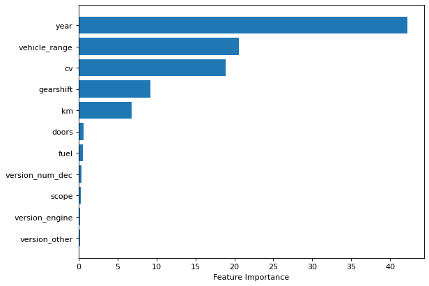

```python
plt.figure(figsize=(8, 6), dpi=80)
plt.barh(y_pos, feature_importance['feature_importance'])
y_pos = np.arange(len(feature_list))
plt.yticks(y_pos, feature_list)
plt.xlabel('Feature Importance')
plt.show()
```

Además, estas features son las que más interaccionan entre ellas.

```python
index_feature = pd.DataFrame({'feature': list(df_x.columns),
                              'feature_index': range(len(df_x.columns))})
index_feature_dict = dict(zip(index_feature.feature_index, index_feature.feature))

interaction_df = cb.CatBoost.get_feature_importance(CBR,
                                type = 'Interaction',
                                prettified=True,
                                thread_count = -1)

interaction_df['First Feature Index'] = interaction_df['First Feature Index'].apply(lambda x: index_feature_dict[x])
interaction_df['Second Feature Index'] = interaction_df['Second Feature Index'].apply(lambda x: index_feature_dict[x])
interaction_df.head()
```

|  | First Feature Index | Second Feature Index | Interaction |
| --- | --- | --- | --- |
| 0 | year | cv | 25.193423 |
| 1 | vehicle_range | year | 17.794110 |
| 2 | km | cv | 12.840905 |
| 3 | vehicle_range | cv | 7.429626 |
| 4 | year | km | 5.029565 |

## Valoración de resultados

Los resultados obtenidos son bastante buenos si consideramos la naturaleza de los datos. Las observaciones se construyen a partir de una información provista por usuarios de internet sin ningún tipo de control. Esto significa que muchas observaciones pueden no ser un reflejo de una tasación franca de un vehículo, pese a que el algoritmo tratará de ajustarse a ellas como si lo fuesen. Además, es común encontrar vehículos averiados e incluso piezas y recambios catalogados como vehículos. Tener esta información en el dataset desvirtua claramente el resultado final.

El modelo tiende a fallar más en terminos porcentuales cuando tiene que predecir el precio de un vehículo muy barato. A medida que el precio aumenta, también lo hace la dispersión a la vez que se reduce el número de observaciones. Esto complica notablemente la modelización respecto a los intervalos de precio menores.

```python
import matplotlib.pyplot as plt

pred = CBR.predict(X_test)
pred_series = pd.Series(pred)
ytest_series = pd.Series(y_test)

pred_series.reset_index(drop=True, inplace=True)
ytest_series.reset_index(drop=True, inplace=True)

comparison = pd.concat([pred_series,ytest_series], axis = 1, ignore_index=True)
comparison.columns = ['predicted_price','real_price']

comparison['predicted_price'] = comparison['predicted_price'].apply(lambda x: round(int(x),-2))
comparison['%dif'] = np.abs(comparison['predicted_price']-comparison['real_price'])*100/comparison['real_price']
comparison['predicted_price'] = np.log(comparison['predicted_price'])
comparison['real_price'] = np.log(comparison['real_price'])

comparison = comparison.sample(frac=1)
comparison = comparison[:300].sort_values(by='real_price').reset_index(drop=True)
```

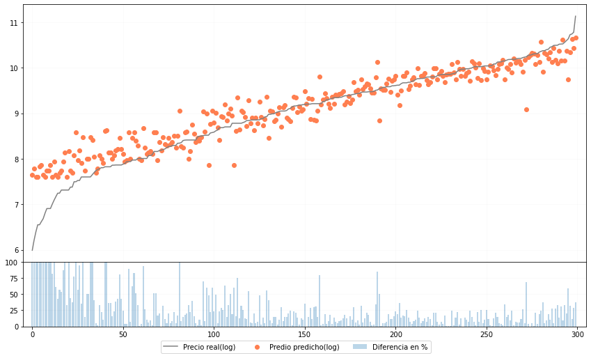

```python
import matplotlib.pyplot as plt

x = comparison.index
y1 = comparison['predicted_price']
y2 = comparison['real_price']
y_diff = comparison['%dif']

fig, (ax1, ax2) = plt.subplots(2, 1,gridspec_kw={'height_ratios': [4, 1]}, sharex=True)
fig.set_size_inches(14.5, 8.5)

ax1.plot(x, y2, c='grey')
ax1.scatter(x, y1, c='coral')
ax2.bar(x, y_diff,alpha=0.3)

ax2.set_ylim([0,100])
ax1.set_xlim([-5,305])
ax2.set_xlim([-5,305])

plt.subplots_adjust(wspace=0, hspace=0)
ax1.grid(which='both',alpha=0.025)
ax2.grid(which='both',alpha=0.025)

fig.legend(['Precio real(log)','Predio predicho(log)','Diferencia en %'], loc='upper center', bbox_to_anchor=(0.5, 0.1), ncol=5)


plt.show()
```

La interpretabilidad de los coeficientes es más costosa en modelos basados en Gradient Boosting debido a que estos son definidos en ramificaciones de condiciones. Sin embargo y con la ayuda del estudio previo, podemos sacar algunas conclusiones. Vemos que la antiguedad tiene a priori un impacto negativo en el precio de venta de un vehículo. Sin embargo, esta tendencia puede revertirse en vehículos considerados clásicos.

La feature referente a la potencia del vehículo parece actuar implicitamente como un indicador de la calidad de los componentes del vehículo, con lo cual está muy vinculada al precio final del vehículo. Además, tiene una notable interacción con la variable año, lo cual reforzaría la hipótesis de que un vehículo de buena calidad se revaloriza con el paso de los años.

## Conclusiones y propuestas de mejora

Hemos visto que incluso con unos datos imperfectos, los algoritmos de Machine Learning son tremendamente poderosos a la hora de identificar patrones y realizar predicciones. No obstante, no podemos dejar de poner atención en que los datos provistos sean de calidad.

No podemos exigirle al programa una tasación equivalente a la que podría dar un profesional si los datos que hemos usado para modelizar no son de esa misma calidad. Es crucial asegurarse de que la metodología de recolección de datos es la adecuada. El algoritmo no deja de aprender de lo que ve, así que si queremos que haga buenas predicciones, debemos nutrirlo con datos excelentes. Por lo tanto, hay que hacer énfasis en la fase de construcción de los datos. Debemos recoger datos de fuentes más fiables y que nos aseguren que las tasaciones han sido realizadas siguiendo determinados criterios.

Dada la naturaleza de nuestros datos, sería importante actualizarlos de forma periódica. La entrada de nuevos modelos en el mercado y los cambios en políticas sobre sostenibilidad producen cambios en la oferta y la demanda de determinados vehículos. Es importante mantener una base de datos actualizada de manera que la muestra sea representativa.

Combinando Web Scraping y Text Mining podría realizarse una extracción de información más completa de las descripciones de los portales, que nos permitiría detectar, por ejemplo, si un vehículo es vendido a piezas o está averiado. Además, podría ampliarse el dataset con nuevas dimensiones que podrían aportar información adicional a nuestros modelos: dimensiones, peso, material, etc. Bases de datos de terceros como Teodalia podrían contribuir a tener un análisis más completo del valor de un vehículo.

Para que el hardware no sea una limitación, podemos acceder a plataformas de computación en la nube como Amazon Web Services o Microsoft Azure. Así, dispondremos de clústeres de equipos con la suficiente potencia para estimar los mejores parámetros para nuestros modelos.

Por último, añadir que es necesario establecer una correcta estrategia de negocio para poder sacar partido del algoritmo. Requerimos del Machine Learning para identificar patrones tan complejos que quedan lejos del entendimiento humano. Esta misma naturaleza es la que nos impide en muchas ocasiones justificar el razonamiento existente tras una decisión.

## Productivización del modelo

Realizamos una pequeña simulación sobre la interfaz construyendo un programa de interacción con el usuario. Puede adaptarse a los casos en los que la marca/modelo no está recogida en la base de datos, advirtiendo de un riesgo de menor precisión. Es un boceto que debería desarrollarse de cara a la implementación en una plataforma como una web o app.

No es necesario proporcionar toda la información con la que se ha entrenado el modelo, pero si la más relevante (como el año, la potencia o los km). Variables como el cambio, el combustible o incluso el rango del vehículo, pueden ser omitidas.

```python
# Consultar si el vehículo es conocido por el algoritmo
import sys
import pickle
import pandas as pd
import numpy as np

with open('included_models.p', 'rb') as im:
    included_models = pickle.load(im)

with open('make_model_to_range.p', 'rb') as mmtr:
    make_model_to_range = pickle.load(mmtr)

df_range_estimator = pd.read_pickle("df_range_estimator.pkl")

filename = 'catboost_car_pricing.sav'
CBR = pickle.load(open(filename, 'rb'))

def start():
    global make, make_lower, model, model_lower, year, decade, cv, km, vehicle_range, gearshift, fuel, doors, scope
    start_val = input("Introduce los parámetros del vehículo en el siguiente formato: marca,año\n").split(",")
    if (len(start_val)!=2) or (start_val[0].isdigit()==True) or (start_val[1].isdigit()==False):
        print("Por favor, introduce los parámetros en el formato correcto: marca,año\n")
        start()
        return
    make, year = start_val
    make_lower = make.lower().replace(' ','-')
    year = int(year)
    model = ''

    if year in range(0,1970):
        decade = 'Anterior a 1970'
    elif year in range(1970,1980):
        decade = '70s'
    elif year in range(1980,1990):
        decade = '80s'
    elif year in range(1990,2000):
        decade = '90s'
    elif year in range(2000,2010):
        decade = '2000s'
    elif year in range(2010,2020):
        decade = '2010s'
    elif year in range(2020,2022):
        decade = '2020s'
    else:
        try_again = print('El año introducido no es válido. ¿Quieres volver a intentarlo?\n')
        try_again_year_func()
        return
    if decade:
        try:
            print("Los modelos conocidos para la marca {} del año {} son los siguientes: {}\n".format(make,year,included_models[make_lower,decade]))
            print("¿Tu modelo aparece en la lista?\n")
            model_known_func()
            return
        except KeyError:
            print("Lo sentimos, este modelo no es muy conocido. Aún podemos intentar darte una tasación ¿Quieres continuar?\n")
            model_unknown_func()
            return

def try_again_year_func():
    global make, make_lower, model, model_lower, year, decade, cv, km, vehicle_range, gearshift, fuel, doors, scope
    try_again = input('(y/n)\n')
    if try_again == 'y':
        start()
    elif try_again == 'n':
        sys.exit("Ejecución finalizada por el usuario.\n")
    else:
        print("Por favor, introduce una respuesta válida.\n")
        try_again_year_func()
        return

def model_known_func():
    global make, make_lower, model, model_lower, year, decade, cv, km, vehicle_range, gearshift, fuel, doors, scope
    model_known = input("(y/n)\n")
    if model_known == 'y':
        model = input("¿A qué modelo pertenece el {}?\n".format(make))
        model_lower = model.lower()[:3]
        model_list = []
        for models in list(included_models[make_lower,decade]):
            model_list.append(models.lower()[:3])
        if model_lower in model_list:
            vehicle_range_cv_km_func()
            return
        else:
            print("No has introducido ningún modelo de la lista. ¿Quieres intentarlo de nuevo?\n")
            model_known_func()
            return
    elif model_known == 'n':
        print("Lo sentimos. Aún podemos intentar darte una tasación ¿Quieres continuar?\n")
        model_unknown_func()
        return
    else:
        print("Por favor, introduce una respuesta válida.\n")
        model_known_func()
        return

def model_unknown_func():
    global make, make_lower, model, model_lower, year, decade, cv, km, vehicle_range, gearshift, fuel, doors, scope
    model_unknown = input("(y/n)\n")
    if model_unknown == 'y':
        vehicle_range_cv_km_func()
        return
    elif model_unknown == 'n':
        sys.exit("Ejecución finalizada por el usuario.\n")
    else:
        print("Por favor, introduce una respuesta válida.\n")
        model_unknown_func()
        return

def vehicle_range_cv_km_func():
    global make, make_lower, model, model_lower, year, decade, cv, km, vehicle_range, gearshift, fuel, doors, scope
    cv_km = input("Introduce los CV y los Km de tu vehículo en el siguiente formato: CV,Km\n").split(",")
    if (len(cv_km)!=2) or (cv_km[0].isdigit()==False) or (cv_km[1].isdigit()==False):
        print("Por favor, introduce los parámetros en el formato correcto: CV, Km\n")
        vehicle_range_cv_km_func()
        return
    cv, km = cv_km
    cv, km = int(cv), int(km)
    if model=='':
        range_assign_df = df_range_estimator.loc[df_range_estimator['decade']==decade].copy()
        range_assign_df['median_cv'] = np.abs(range_assign_df['median_cv']-cv)
        range_assign_df = range_assign_df.sort_values(by='median_cv')
        vehicle_range = range_assign_df.iloc[0][0]
    else:
        vehicle_range = make_model_to_range[(make_lower,model_lower,decade)]
    print("Ya casi hemos terminado. ¿Podrías indicarnos algunos datos más?\n")
    gearshift_func()
    return

def gearshift_func():
    global make, make_lower, model, model_lower, year, decade, cv, km, vehicle_range, gearshift, fuel, doors, scope
    print("¿Qué tipo de cambio tiene el vehículo? Por favor, indica la respuesta con el número correspondiente:\n")
    options_gearshift = ['Automático','Manual','Desconocido']
    for i, element in enumerate(options_gearshift):
        print("{}) {}".format(i+1,element))
    gearshift = input("")
    if (gearshift.isdigit()==True):
        gearshift = int(gearshift)
    else:
        print("El valor introducido es incorrecto. Por favor, vuelve a intentarlo.\n")
        gearshift_func()
        return
    if 0 < gearshift <= len(options_gearshift):
        print("Cambio del vehículo: {}\n".format(options_gearshift[gearshift-1]))
        gearshift = options_gearshift[gearshift-1]
        fuel_func()
        return
    else:
        print("El valor introducido es incorrecto. Por favor, vuelve a intentarlo.\n")
        gearshift_func()
        return

def fuel_func():
    global make, make_lower, model, model_lower, year, decade, cv, km, vehicle_range, gearshift, fuel, doors, scope
    print("¿Qué tipo de combustible usa el vehículo? Por favor, indica la respuesta con el número correspondiente:\n")
    options_fuel = ['Gasolina','Diesel','Desconocido']
    for i, element in enumerate(options_fuel):
        print("{}) {}".format(i+1,element))
    fuel = input("")
    if (fuel.isdigit()==True):
        fuel = int(fuel)
    else:
        print("El valor introducido es incorrecto. Por favor, vuelve a intentarlo.\n")
        fuel_func()
        return
    if 0 < fuel <= len(options_fuel):
        print("Combustible del vehículo: {}\n".format(options_fuel[fuel-1]))
        fuel = options_fuel[fuel-1]
        doors_func()
        return
    else:
        print("El valor introducido es incorrecto. Por favor, vuelve a intentarlo.\n")
        fuel_func()
        return

def doors_func():
    global make, make_lower, model, model_lower, year, decade, cv, km, vehicle_range, gearshift, fuel, doors, scope
    print("¿Cuántas puertas tiene el vehículo? Por favor, indica la respuesta con el número correspondiente:\n")
    options_doors = ['2 puertas','3 puertas','4 puertas','5 puertas','Desconocido']
    for i, element in enumerate(options_doors):
        print("{}) {}".format(i+2,element))
    doors = input("")
    if (doors.isdigit()==True):
        doors = int(doors)
    else:
        print("El valor introducido es incorrecto. Por favor, vuelve a intentarlo.\n")
        doors_func()
        return
    if 1 < doors <= len(options_doors)+1:
        print("Número de puertas del vehículo: {}\n".format(options_doors[doors-2]))
        doors = options_doors[doors-2]
        scope_func()
        return
    else:
        print("El valor introducido es incorrecto. Por favor, vuelve a intentarlo.\n")
        doors_func()
        return

def scope_func():
    global make, make_lower, model, model_lower, year, decade, cv, km, vehicle_range, gearshift, fuel, doors, scope
    print("¿El vehículo está ofertado por un concesionario/profesional? Por favor, indica la respuesta con el número correspondiente:\n")
    options_scope = ['Sí','No','Desconocido']
    for i, element in enumerate(options_scope):
        print("{}) {}".format(i+1,element))
    scope = input("")
    if (scope.isdigit()==True):
        scope = int(scope)
    else:
        print("El valor introducido es incorrecto. Por favor, vuelve a intentarlo.\n")
        scope_func()
        return
    if 0 < scope <= len(options_scope):
        print("El vehículo está ofertado por un concesionario/profesional: {}\n".format(options_scope[scope-1]))
        scope = options_scope[scope-1]
        end_func()
        return
    else:
        print("El valor introducido es incorrecto. Por favor, vuelve a intentarlo.\n")
        scope_func()
        return

def end_func():
    global make, make_lower, model, model_lower, year, decade, cv, km, vehicle_range, gearshift, fuel, doors, scope
    print("Por último, introduce el nombre completo del vehículo (si no lo conoces, deja este campo en blanco):\n")
    version_tags = input("Ejemplo: Enjoy 1.3 CDTi\n").lower().split(" ")
    lista_version_num_dec = ['1.0','1.2','1.4','1.5','1.6','1.9','2.0']
    lista_version_engine = ['d','tdi','s&s','dci','hdi','tdci','tsi','bluehdi']
    lista_version_other = ['sport','style','advance','4x2']
    version_num_dec = 'other'
    version_engine = 'other'
    version_other = 'other'
    for tag in lista_version_num_dec:
        if tag in version_tags:
            version_num_dec = tag
    for tag in lista_version_engine:
        if tag in version_tags:
            version_engine = tag
    for tag in lista_version_other:
        if tag in version_tags:
            version_other = tag
    # Si se ha indicado desconocido en un parámetro, se asigna el más genérico (5 puertas/cambio manual/gasolina...)
    if gearshift =='Desconocido':
        gearshift == 'Manual'
    if fuel =='Desconocido':
        fuel = 'Gasolina'
    if doors =='Desconocido':
        doors = '5 puertas'
    if scope =='Desconocido':
        scope = 'No'
    if scope =='Sí':
        scope = 'Profesional'
    if scope =='No':
        scope = 'Particular'
    gearshift = gearshift.lower()
    fuel = fuel.lower()
    doors = doors.lower()
    scope = scope.lower()

    #Preparamos el dataset para la predicción
    data = {'vehicle_range': 'vehicle_range_5',
            'year': [year],
            'km': [km],
            'cv': [cv],
            'fuel': [fuel],
            'gearshift': [gearshift],
            'doors': [doors],
            'scope': [scope],
            'version_num_dec': [version_num_dec],
            'version_engine': [version_engine],
            'version_other': [version_other]}

    df_input = pd.DataFrame(data)
    print("El valor de tu vehículo es de {} euros.".format(round(int(CBR.predict(df_input)),-2)))
```

Con el comando start() podemos llamar al programa de tasación.

```python
start()
```

```
Introduce los parámetros del vehículo en el siguiente formato: marca,año
Opel,2008
Los modelos conocidos para la marca Opel del año 2008 son los siguientes: ['Zafira', 'Tigra', 'Corsa', 'Meriva', 'Antara', 'Astra', 'Insignia', 'Vectra', 'Frontera', 'Vivaro', 'Zafira Life', 'Signum', 'Movano', 'Omega', 'GTC', 'CORSA-E', 'Combo', 'Agila', 'MOKKA-E', 'Zafira Tourer', 'COMBO LIFE', 'Z…

¿Tu modelo aparece en la lista?

(y/n)
y
¿A qué modelo pertenece el Opel?
Corsa
Introduce los CV y los Km de tu vehículo en el siguiente formato: CV,Km
75,210000
Ya casi hemos terminado. ¿Podrías indicarnos algunos datos más?

¿Qué tipo de cambio tiene el vehículo? Por favor, indica la respuesta con el número correspondiente:

1) Automático
2) Manual
3) Desconocido
2
Cambio del vehículo: Manual

¿Qué tipo de combustible usa el vehículo? Por favor, indica la respuesta con el número correspondiente:

1) Gasolina
2) Diesel
3) Desconocido
2
Combustible del vehículo: Diesel

¿Cuántas puertas tiene el vehículo? Por favor, indica la respuesta con el número correspondiente:

2) 2 puertas
3) 3 puertas
4) 4 puertas
5) 5 puertas
6) Desconocido
5
Número de puertas del vehículo: 5 puertas

¿El vehículo está ofertado por un concesionario/profesional? Por favor, indica la respuesta con el número correspondiente:

1) Sí
2) No
3) Desconocido
2
El vehículo está ofertado por un concesionario/profesional: No

Por último, introduce el nombre completo del vehículo (si no lo conoces, deja este campo en blanco):

Ejemplo: Enjoy 1.3 CDTi
Enjoy 1.3 cdti
El valor de tu vehículo es de 2800 euros.
```